# Berlin CO2 Leistungsbild

Bhaskar Kamble

15 August 2019

General Notes:

Have all co2 emissions for the Bezirke ready, then add then up to find the co2 for berlin

You can compare the sum of all bezirke with the total for Berlin also

Use this:

file:///D:/GITHUB_REPOS/co2emissions/Berlin/BezirkAnalysis/01_charlottenburg_wilmersdorf/ExtractData2.R

Important variables:

- berlin_co2_all: kilo tons of co2 emitted by each bezirk in each year. (all = mfh+sfh)
- bezirk_areas_all: areas of each bezirk in each year.
- bezirk_spez_co2: per unit area co2 emitted by each bezirk in each year.
- bezirke_spez_co2_linea: linear trend of bezirke_spez_co2
- spez_co2_emission: berlin all buildings, specific co2 emissions for each year
- bezirk_population: population of each bezirk in each year for mfh+sfh.

```r
source("D:/GITHUB_REPOS/co2emissions/Berlin/BezirkAnalysis/getAllBezirkeTotalCO2_v2.R")
alle_bezirke_co2 <- getAllBezirkeTotalCO2()
```

```r
i_section <- 1
```

# 1. Alle Stadtbezirke, CO2-Emission aus Beheizung, alle Wohngebäude

```r
i_subsection <- 1
```

## 1.1 Absolute Zahlen

```r
i_subsubsection <- 1
```

### 1.1.1 Berlin, MFH + 1-2 FH, CO2-Emission aus der Beheizung von Wohnraum 2002-2018 in 1.000 t

- Berlin, summed over all Bezirke and all Energieträger.
- Berlin, summed over all Bezirke, split by Energieträger.

```r
#alle_bezirke_co2$all - datatframe of year, and co2 emissions of each bezirk , summed over ET.
berlin_co2_all <- getRowSums(alle_bezirke_co2$all , dropCols = "abrechnungsjahr")
berlin_co2_all
```

```
##    abrechnungsjahr charlottenburg_wilmersdorf friedrichshain_kreuzberg
## 1             2002                   437.5293                 297.2324
## 2             2003                   466.5623                 288.0173
## 3             2004                   523.9296                 267.8083
## 4             2005                   499.0712                 269.5375
## 5             2006                   506.4530                 287.4582
## 6             2007                   467.4310                 260.4179
## 7             2008                   471.6374                 257.8947
## 8             2009                   397.8959                 252.1482
## 9             2010                   497.1840                 300.9858
## 10            2011                   439.2849                 238.1180
## 11            2012                   463.8478                 260.7414
## 12            2013                   460.5407                 236.0173
## 13            2014                   338.4202                 191.1728
## 14            2015                   314.9513                 190.9628
```

[output cut: 57 more lines]

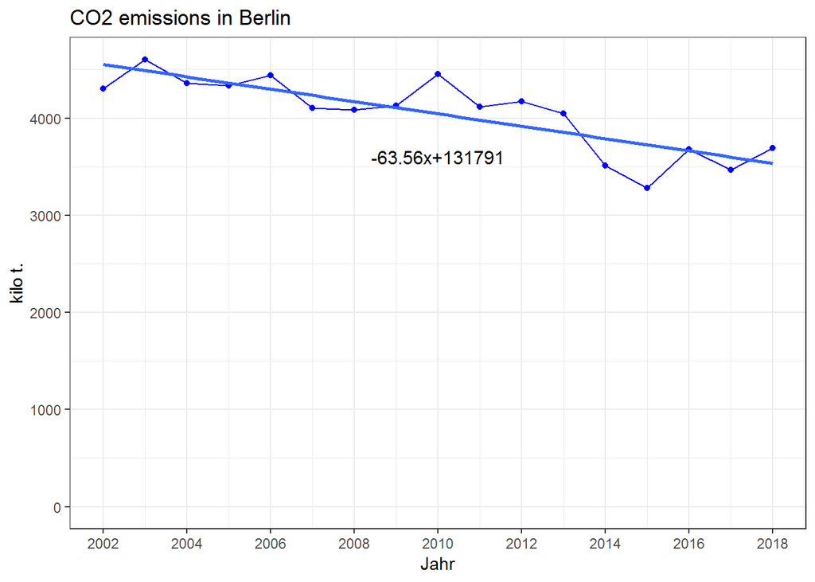

```r
#plot(berlin_co2_all$abrechnungsjahr , berlin_co2_all$total)
require(ggplot2)
#look at line 187 of BerlinPresentationCO2BalanceUnified_v6.Rmd
points_line_lm <- function(input_data,
                           xVar,
                           yVar,
                           ymin,
                           ymax,
                           x_eq=2008,
                           y_eq=2500,
                           size_eq=6,
                           plot_title,
                           xlab,
                           ylab,
                           slope_round_to = 2,
                           intercept_round_to = 0) {
  linmod <- lm(data=input_data , formula = get(yVar)~get(xVar))
  coeff_a <- as.numeric(coefficients(linmod)[1])
  coeff_b <- as.numeric(coefficients(linmod)[2])
  if (coeff_a<0) {
    sign_coeff_a <- " "
  } else {sign_coeff_a <- "+"}


  b_round <- as.character(round(coeff_b,slope_round_to))
  a_round <- as.character(round(coeff_a,intercept_round_to))
  lm_equation <- paste0( b_round , "x" , sign_coeff_a ,  a_round)

  g <- ggplot() + geom_line(data=input_data , aes(x=get(xVar) , y=get(yVar)) , color="blue"
  )+geom_point(data=input_data , aes(x=get(xVar) , y=get(yVar)) , color="blue"
  )+geom_smooth(method="lm" , data=input_data , aes(x=get(xVar) , y=get(yVar)) , se=FALSE
  )+annotate(geom="text" , label=lm_equation , x = x_eq , y = y_eq , size=size_eq
  )+ylim(ymin,ymax)+scale_x_continuous(breaks=seq(2002,2018,2)
  )+theme_bw()+labs(x=xlab,
  y=ylab,title=plot_title)
  return(g)
}
points_line_lm(input_data = berlin_co2_all,
               xVar = "abrechnungsjahr",
               yVar = "total",
               ymin = 0,
               ymax = max(berlin_co2_all$total),
               x_eq = 2010,
               y_eq = 3600,
               size_eq = 4,
               plot_title = "CO2 emissions in Berlin",
               xlab = "Jahr",
               ylab = "kilo t.")
```

- Now you should write a new function which gives the CO2 emission of Berlin, MFH+SFH, summed over all Bezirke, and split by ET.

```r
source("D:/GITHUB_REPOS/co2emissions/Berlin/BezirkAnalysis/getAllBezirkeByETCO2_v2.R")
co2_allebezirke_byET <- getAllBezirkeByETCO2()
co2_all_allebezirke_byET <- co2_allebezirke_byET$all
co2_all_allebezirke_byET
```

```
##    abrechnungsjahr   erdgas   waerme fluessiggas  heizoel holzpellets
## 1             2002 1746.306 440.6780    0.000000 2034.860  0.00000000
## 2             2003 1507.779 356.8875    0.000000 2661.570  0.00000000
## 3             2004 1463.165 349.5755    1.927683 2467.567  0.00000000
## 4             2005 1696.369 331.3529    7.738564 2219.900  0.04967672
## 5             2006 1859.785 324.0964    8.583952 2168.262  0.05636583
## 6             2007 1653.945 329.6998    3.774203 2038.044  0.05977333
## 7             2008 1647.829 346.3019   23.237083 1986.111  0.18485772
## 8             2009 1794.166 433.4917   19.659725 1799.082  0.47207509
## 9             2010 1580.796 458.9509   10.065080 2377.492  0.74027282
## 10            2011 1503.528 369.4881   13.736308 2190.026  1.54561390
## 11            2012 1518.224 319.8752   33.103532 2246.576  1.86321340
## 12            2013 1604.555 377.2518   19.693120 2015.530  2.05043255
## 13            2014 1416.577 346.0610   10.428462 1694.626  0.32888674
## 14            2015 1433.409 516.9907    9.235242 1235.567  1.17639896
```

[output cut: 21 more lines]

```r
require(ggplot2)
col_list <- c("royalblue4","orangered1","gray59","orange","blue","olivedrab4")
cols <- c(
          "erdgas"      = "royalblue4",
          "waerme"      = "orangered1",
          "fluessiggas" = "gray59",
          "heizoel"     = "orange",
          "holzpellets" = "blue",
          "strom"       = "olivedrab4"
          )
plot_title <- NULL
order_legend <- rev(c("erdgas","waerme","fluessiggas","heizoel","holzpellets","strom"))
order_labels <- rev(c("Erdgas","Wärme (N+F)","Flüssiggas","Heizöl","Holzpellets","Strom (D+WP)"))
et_list <- c("erdgas","waerme","fluessiggas","heizoel","holzpellets","strom")
plot_byET <- function(obj,xlabel,ylabel,plottitle) {
  ggplot()+geom_line(data=obj,aes(x=abrechnungsjahr,y=get(et_list[1]),color=et_list[1]),size=5
  )+geom_line(data=obj,aes(x=abrechnungsjahr,y=get(et_list[2]),color=et_list[2])
  )+geom_line(data=obj,aes(x=abrechnungsjahr,y=get(et_list[3]),color=et_list[3])
  )+geom_line(data=obj,aes(x=abrechnungsjahr,y=get(et_list[4]),color=et_list[4])
  )+geom_line(data=obj,aes(x=abrechnungsjahr,y=get(et_list[5]),color=et_list[5])
  )+geom_line(data=obj,aes(x=abrechnungsjahr,y=get(et_list[6]),color=et_list[6])
  )+scale_color_manual(labels=order_labels,name=" ",values=cols,breaks=order_legend
  )+geom_ribbon(data=obj,aes(x=abrechnungsjahr,ymin=0,ymax=get(et_list[6])),fill=col_list[6]
  )+geom_ribbon(data=obj,aes(x=abrechnungsjahr,ymin=0,ymax=get(et_list[5])),fill=col_list[5]
  )+geom_ribbon(data=obj,aes(x=abrechnungsjahr,ymin=0,ymax=get(et_list[4])),fill=col_list[4]
  )+geom_ribbon(data=obj,aes(x=abrechnungsjahr,ymin=0,ymax=get(et_list[3])),fill=col_list[3]
  )+geom_ribbon(data=obj,aes(x=abrechnungsjahr,ymin=0,ymax=get(et_list[2])),fill=col_list[2]
  )+geom_ribbon(data=obj,aes(x=abrechnungsjahr,ymin=0,ymax=get(et_list[1])),fill=col_list[1])+theme_bw()+ labs(x=xlabel,y=ylabel,title=plottitle) + theme(plot.title=element_text(size=30), axis.title.x=element_text(size=20, face="bold"), axis.title.y=element_text(size=20, face="bold"), legend.text = element_text(size=15), axis.text.x=element_text(size=15,face="bold"), axis.text.y=element_text(size=15,face="bold"), legend.key.size=unit(2, "lines")
  )+scale_x_continuous(breaks=seq(2002,2018,2))
}
```

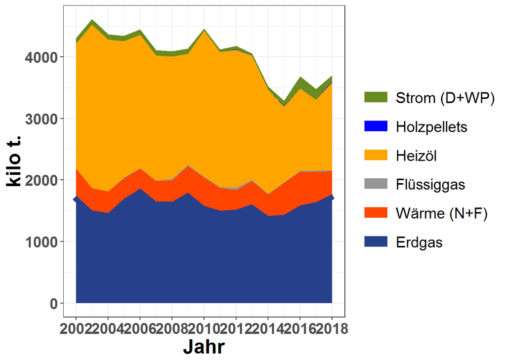

```r
source("D:/GITHUB_REPOS/co2emissions/Berlin/BezirkAnalysis/getCumSums.R")
co2_all_allebezirke_byET_cumsums <- getCumSums(obj=co2_all_allebezirke_byET , dropCols=c("abrechnungsjahr","total"))
#co2_all_allebezirke_byET_cumsums
plot_byET(co2_all_allebezirke_byET_cumsums , xlabel = "Jahr" , ylabel = "kilo t." , plottitle = NULL)
```

```r
i_subsubsection <- i_subsubsection + 1
```

### 1.1.2 Stadtbezirke, MFH + 1-2 FH, CO2-Emission aus der Beheizung von Wohnraum 2002-2018 summiert in 1.000 t

- Here split by the Bezirke

```r
berlin_co2_all
```

```
##    abrechnungsjahr charlottenburg_wilmersdorf friedrichshain_kreuzberg
## 1             2002                   437.5293                 297.2324
## 2             2003                   466.5623                 288.0173
## 3             2004                   523.9296                 267.8083
## 4             2005                   499.0712                 269.5375
## 5             2006                   506.4530                 287.4582
## 6             2007                   467.4310                 260.4179
## 7             2008                   471.6374                 257.8947
## 8             2009                   397.8959                 252.1482
## 9             2010                   497.1840                 300.9858
## 10            2011                   439.2849                 238.1180
## 11            2012                   463.8478                 260.7414
## 12            2013                   460.5407                 236.0173
## 13            2014                   338.4202                 191.1728
## 14            2015                   314.9513                 190.9628
```

[output cut: 57 more lines]

```r
bezirk_list <- names(berlin_co2_all)[!(names(berlin_co2_all)%in% c("abrechnungsjahr","total"))]
bezirk_list
```

```
##  [1] "charlottenburg_wilmersdorf" "friedrichshain_kreuzberg"
##  [3] "lichtenberg"                "marzahn_hellersdorf"
##  [5] "mitte"                      "neukoelln"
##  [7] "pankow"                     "reinickendorf"
##  [9] "spandau"                    "steglitz_zehlendorf"
## [11] "tempelhof_schoeneberg"      "treptow_koepenick"
```

```r
berlin_co2_all_cumsums <- getCumSums(obj=berlin_co2_all , dropCols=c("abrechnungsjahr","total"))
```

The following is simply for trying. Here I am putting simply the line plots.

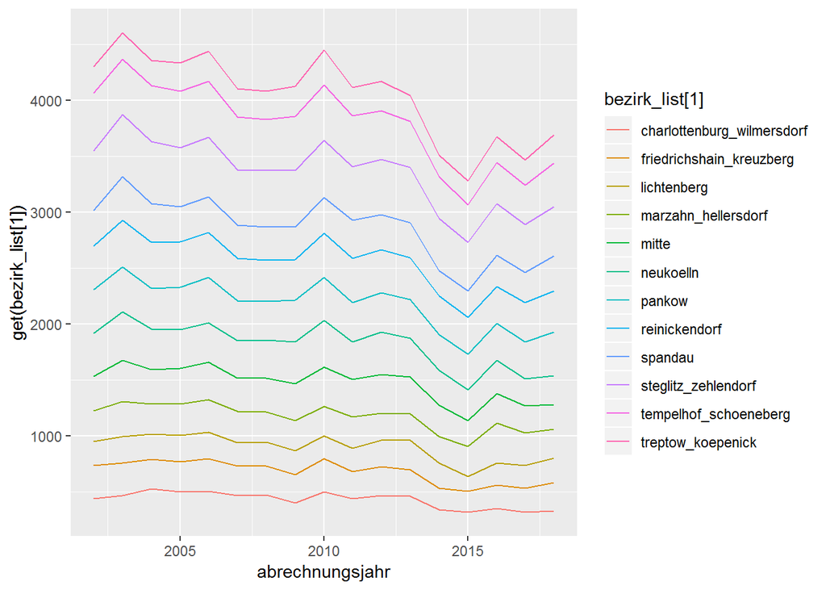

```r
obj <- berlin_co2_all_cumsums
ggplot()+geom_line(data=obj,aes(x=abrechnungsjahr,y=get(bezirk_list[1]),color=bezirk_list[1])
)+geom_line(data=obj,aes(x=abrechnungsjahr,y=get(bezirk_list[2]),color=bezirk_list[2])
)+geom_line(data=obj,aes(x=abrechnungsjahr,y=get(bezirk_list[3]),color=bezirk_list[3])
)+geom_line(data=obj,aes(x=abrechnungsjahr,y=get(bezirk_list[4]),color=bezirk_list[4])
)+geom_line(data=obj,aes(x=abrechnungsjahr,y=get(bezirk_list[5]),color=bezirk_list[5])
)+geom_line(data=obj,aes(x=abrechnungsjahr,y=get(bezirk_list[6]),color=bezirk_list[6])
)+geom_line(data=obj,aes(x=abrechnungsjahr,y=get(bezirk_list[7]),color=bezirk_list[7])
)+geom_line(data=obj,aes(x=abrechnungsjahr,y=get(bezirk_list[8]),color=bezirk_list[8])
)+geom_line(data=obj,aes(x=abrechnungsjahr,y=get(bezirk_list[9]),color=bezirk_list[9])
)+geom_line(data=obj,aes(x=abrechnungsjahr,y=get(bezirk_list[10]),color=bezirk_list[10])
)+geom_line(data=obj,aes(x=abrechnungsjahr,y=get(bezirk_list[11]),color=bezirk_list[11])
)+geom_line(data=obj,aes(x=abrechnungsjahr,y=get(bezirk_list[12]),color=bezirk_list[12])
)
```

Now I try to put the lines as well as the ribbons:

```r
gg_color_hue <- function(n) {
  hues = seq(15, 375, length = n + 1)
  hcl(h = hues, l = 65, c = 100)[1:n]
}
cols_bezirk <- gg_color_hue(12)
names(cols_bezirk) <- bezirk_list
order_legend_bez <- bezirk_list
order_labels_bez <- bezirk_list
```

Put it all together into a function:

```r
plot_byBezirke <- function(obj,xlabel,ylabel,plottitle) {
ggplot()+geom_line(data=obj,aes(x=abrechnungsjahr,y=get(bezirk_list[1]),color=bezirk_list[1]),size=5
)+geom_line(data=obj,aes(x=abrechnungsjahr,y=get(bezirk_list[2]),color=bezirk_list[2])
)+geom_line(data=obj,aes(x=abrechnungsjahr,y=get(bezirk_list[3]),color=bezirk_list[3])
)+geom_line(data=obj,aes(x=abrechnungsjahr,y=get(bezirk_list[4]),color=bezirk_list[4])
)+geom_line(data=obj,aes(x=abrechnungsjahr,y=get(bezirk_list[5]),color=bezirk_list[5])
)+geom_line(data=obj,aes(x=abrechnungsjahr,y=get(bezirk_list[6]),color=bezirk_list[6])
)+geom_line(data=obj,aes(x=abrechnungsjahr,y=get(bezirk_list[7]),color=bezirk_list[7])
)+geom_line(data=obj,aes(x=abrechnungsjahr,y=get(bezirk_list[8]),color=bezirk_list[8])
)+geom_line(data=obj,aes(x=abrechnungsjahr,y=get(bezirk_list[9]),color=bezirk_list[9])
)+geom_line(data=obj,aes(x=abrechnungsjahr,y=get(bezirk_list[10]),color=bezirk_list[10])
)+geom_line(data=obj,aes(x=abrechnungsjahr,y=get(bezirk_list[11]),color=bezirk_list[11])
)+geom_line(data=obj,aes(x=abrechnungsjahr,y=get(bezirk_list[12]),color=bezirk_list[12])
)+scale_color_manual(labels=order_labels_bez,name=" ",values=cols_bezirk,breaks=order_legend_bez
)+geom_ribbon(data=obj,aes(x=abrechnungsjahr,ymin=0,ymax=get(bezirk_list[12])),fill=cols_bezirk[12]
)+geom_ribbon(data=obj,aes(x=abrechnungsjahr,ymin=0,ymax=get(bezirk_list[11])),fill=cols_bezirk[11]
)+geom_ribbon(data=obj,aes(x=abrechnungsjahr,ymin=0,ymax=get(bezirk_list[10])),fill=cols_bezirk[10]
)+geom_ribbon(data=obj,aes(x=abrechnungsjahr,ymin=0,ymax=get(bezirk_list[9])),fill=cols_bezirk[9]
)+geom_ribbon(data=obj,aes(x=abrechnungsjahr,ymin=0,ymax=get(bezirk_list[8])),fill=cols_bezirk[8]
)+geom_ribbon(data=obj,aes(x=abrechnungsjahr,ymin=0,ymax=get(bezirk_list[7])),fill=cols_bezirk[7]
)+geom_ribbon(data=obj,aes(x=abrechnungsjahr,ymin=0,ymax=get(bezirk_list[6])),fill=cols_bezirk[6]
)+geom_ribbon(data=obj,aes(x=abrechnungsjahr,ymin=0,ymax=get(bezirk_list[5])),fill=cols_bezirk[5]
)+geom_ribbon(data=obj,aes(x=abrechnungsjahr,ymin=0,ymax=get(bezirk_list[4])),fill=cols_bezirk[4]
)+geom_ribbon(data=obj,aes(x=abrechnungsjahr,ymin=0,ymax=get(bezirk_list[3])),fill=cols_bezirk[3]
)+geom_ribbon(data=obj,aes(x=abrechnungsjahr,ymin=0,ymax=get(bezirk_list[2])),fill=cols_bezirk[2]
)+geom_ribbon(data=obj,aes(x=abrechnungsjahr,ymin=0,ymax=get(bezirk_list[1])),fill=cols_bezirk[1]
)+theme_bw()+ labs(x=xlabel,y=ylabel,title=plottitle) + theme(plot.title=element_text(size=10), axis.title.x=element_text(size=10, face="bold"), axis.title.y=element_text(size=10, face="bold"), legend.text = element_text(size=8), axis.text.x=element_text(size=15,face="bold"), axis.text.y=element_text(size=12,face="bold"), legend.key.size=unit(2, "lines"),legend.position = "bottom"
)+scale_x_continuous(breaks=seq(2002,2018,2))
}
```

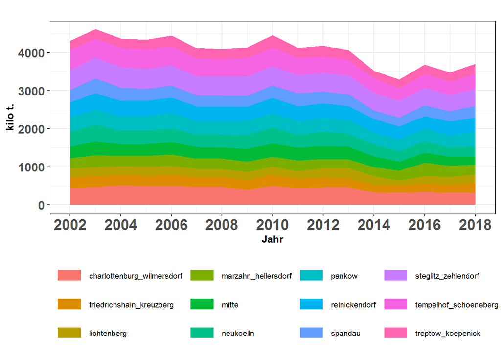

```r
plot_byBezirke(berlin_co2_all_cumsums , xlabel = "Jahr" , ylabel = "kilo t." , plottitle="")
```

```r
i_subsubsection <- i_subsubsection + 1
```

### 1.1.3 Stadtbezirke, MFH + 1-2 FH, CO2-Emission aus der Beheizung von Wohnraum 2002-2018 in Prozent

- Here the percent of the co2 emission broken up by percentage - by ET first, and then by bezirk.
- The function `find_proportions` is to be used for this purpose.

```r
find_proportions
```

```
## function (obj, drop_cols)
## {
##     obj <- obj[, !(names(obj) %in% drop_cols)]
##     obj <- obj/rowSums(obj)
##     obj <- 100 * obj
##     obj$abrechnungsjahr <- 2002:2018
##     return(obj)
## }
## <bytecode: 0x0000000026a99bd0>
```

```r
co2_all_allebezirke_byET
```

```
##    abrechnungsjahr   erdgas   waerme fluessiggas  heizoel holzpellets
## 1             2002 1746.306 440.6780    0.000000 2034.860  0.00000000
## 2             2003 1507.779 356.8875    0.000000 2661.570  0.00000000
## 3             2004 1463.165 349.5755    1.927683 2467.567  0.00000000
## 4             2005 1696.369 331.3529    7.738564 2219.900  0.04967672
## 5             2006 1859.785 324.0964    8.583952 2168.262  0.05636583
## 6             2007 1653.945 329.6998    3.774203 2038.044  0.05977333
## 7             2008 1647.829 346.3019   23.237083 1986.111  0.18485772
## 8             2009 1794.166 433.4917   19.659725 1799.082  0.47207509
## 9             2010 1580.796 458.9509   10.065080 2377.492  0.74027282
## 10            2011 1503.528 369.4881   13.736308 2190.026  1.54561390
## 11            2012 1518.224 319.8752   33.103532 2246.576  1.86321340
## 12            2013 1604.555 377.2518   19.693120 2015.530  2.05043255
## 13            2014 1416.577 346.0610   10.428462 1694.626  0.32888674
## 14            2015 1433.409 516.9907    9.235242 1235.567  1.17639896
```

[output cut: 21 more lines]

```r
co2_all_allebezirke_byET_prop <- find_proportions(co2_all_allebezirke_byET , drop_cols = c("abrechnungsjahr","total"))
co2_all_allebezirke_byET_prop
```

```
##      erdgas    waerme fluessiggas  heizoel holzpellets     strom
## 1  40.60830 10.247450  0.00000000 47.31829 0.000000000 1.8259637
## 2  32.74392  7.750406  0.00000000 57.80041 0.000000000 1.7052606
## 3  33.55300  8.016393  0.04420523 56.58573 0.000000000 1.8006765
## 4  39.14156  7.645548  0.17855753 51.22137 0.001146227 1.8118217
## 5  41.89359  7.300609  0.19336246 48.84235 0.001269699 1.7688156
## 6  40.30036  8.033531  0.09196299 49.65938 0.001456449 1.9133108
## 7  40.36632  8.483244  0.56923121 48.65312 0.004528399 1.9235557
## 8  43.49077 10.507883  0.47655375 43.60994 0.011443148 1.9034090
## 9  35.51808 10.311930  0.22614706 53.41863 0.016632807 0.5085814
## 10 36.52616  8.976212  0.33370492 53.20371 0.037548588 0.9226579
## 11 36.39305  7.667669  0.79351856 53.85225 0.044662740 1.2488449
## 12 39.65099  9.322463  0.48664683 49.80681 0.050669294 0.6824271
## 13 40.36449  9.860797  0.29715268 48.28734 0.009371427 1.1808565
## 14 43.69795 15.760633  0.28153940 37.66667 0.035862909 2.5573486
```

[output cut: 21 more lines]

```r
co2_all_allebezirke_byET_prop_cumsums <- getCumSums(obj=co2_all_allebezirke_byET_prop , dropCols = "abrechnungsjahr")
co2_all_allebezirke_byET_prop_cumsums
```

```
##      erdgas   waerme fluessiggas  heizoel holzpellets strom
## 1  40.60830 50.85575    50.85575 98.17404    98.17404   100
## 2  32.74392 40.49433    40.49433 98.29474    98.29474   100
## 3  33.55300 41.56939    41.61360 98.19932    98.19932   100
## 4  39.14156 46.78711    46.96566 98.18703    98.18818   100
## 5  41.89359 49.19420    49.38756 98.22991    98.23118   100
## 6  40.30036 48.33389    48.42585 98.08523    98.08669   100
## 7  40.36632 48.84956    49.41880 98.07192    98.07644   100
## 8  43.49077 53.99866    54.47521 98.08515    98.09659   100
## 9  35.51808 45.83001    46.05616 99.47479    99.49142   100
## 10 36.52616 45.50237    45.83608 99.03979    99.07734   100
## 11 36.39305 44.06072    44.85424 98.70649    98.75116   100
## 12 39.65099 48.97345    49.46010 99.26690    99.31757   100
## 13 40.36449 50.22528    50.52244 98.80977    98.81914   100
## 14 43.69795 59.45858    59.74012 97.40679    97.44265   100
```

[output cut: 21 more lines]

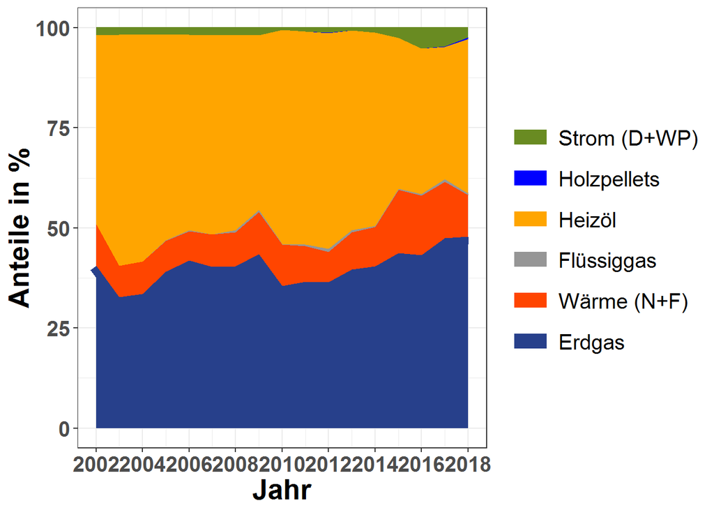

```r
plot_byET(co2_all_allebezirke_byET_prop_cumsums,xlabel = "Jahr" , ylabel = "Anteile in %" , plottitle = NULL)
```

```r
berlin_co2_all
```

```
##    abrechnungsjahr charlottenburg_wilmersdorf friedrichshain_kreuzberg
## 1             2002                   437.5293                 297.2324
## 2             2003                   466.5623                 288.0173
## 3             2004                   523.9296                 267.8083
## 4             2005                   499.0712                 269.5375
## 5             2006                   506.4530                 287.4582
## 6             2007                   467.4310                 260.4179
## 7             2008                   471.6374                 257.8947
## 8             2009                   397.8959                 252.1482
## 9             2010                   497.1840                 300.9858
## 10            2011                   439.2849                 238.1180
## 11            2012                   463.8478                 260.7414
## 12            2013                   460.5407                 236.0173
## 13            2014                   338.4202                 191.1728
## 14            2015                   314.9513                 190.9628
```

[output cut: 57 more lines]

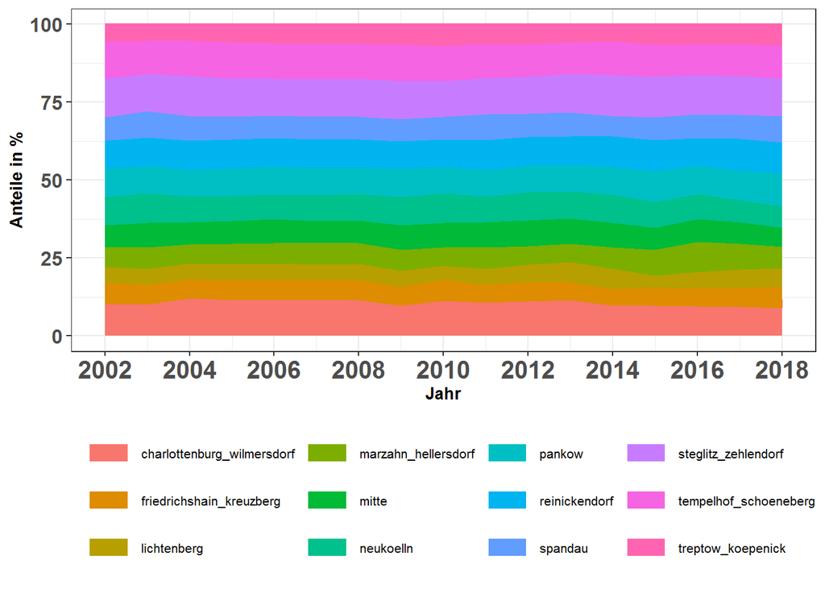

```r
berlin_co2_all_prop <- find_proportions(berlin_co2_all,drop_cols=c("abrechnungsjahr","total"))
berlin_co2_all_prop_cumsums <- getCumSums(berlin_co2_all_prop,dropCols="abrechnungsjahr")
plot_byBezirke(berlin_co2_all_prop_cumsums,xlabel = "Jahr" , ylabel = "Anteile in %" , plottitle = NULL)
```

```r
i_subsubsection <- i_subsubsection + 1
```

### 1.1.4 Stadtbezirke, MFH + 1-2 FH, CO2-Emission aus der Beheizung von Wohnraum 2002-2018 in 1.000 t

Same as 1.1.2.

```r
i_subsubsection <- i_subsubsection + 1
```

### 1.1.5 Stadtbezirke, MFH + 1-2 FH, CO2-Emission aus der Beheizung von Wohnraum 2002-2018, Veränderung in Prozent

- Pending

```r
i_subsubsection <- i_subsubsection + 1
```

### 1.1.6 Stadtbezirke, MFH + 1-2 FH, CO2-Emission aus der Beheizung von Wohnraum 2002-2018, in Prozent

- Pending

```r
i_subsection <- i_subsection + 1
```

## 1.2 Flächenbezug

```r
i_subsubsection <- 1
```

### 1.2.1 Berlin, MFH + 1-2 FH, flächenbezogene co2 Emission aus der Beheizung von Wohnraum 2002-2018 in kg/m2 [AN]

Here you have to get the areas of SFH and MFH buildings…

- Short method: Do as in BerlinPresentationCO2BalanceUnified_v7.Rmd. I.e. read directly from the file for total Berlin areas.

```r
totalArea <- read.table("D:/GITHUB_REPOS/co2emissions/Berlin/berlin_wohnflaeche.txt",header=TRUE)
totalArea <- totalArea*1000000
totalArea$totArea <- rowSums(totalArea)
totalArea$abrechnungsjahr <- 2002:2018
#totalArea <- totalArea[ , c("abrechnungsjahr","totArea")]
totalArea
```

```
##         SFH       MFH   totArea abrechnungsjahr
## 1  28193000 127248000 155441000            2002
## 2  28525000 127792000 156317000            2003
## 3  28963000 128230000 157193000            2004
## 4  29345000 128723000 158068000            2005
## 5  29751000 129193000 158944000            2006
## 6  30173000 129647000 159820000            2007
## 7  30495000 130200000 160695000            2008
## 8  30770000 130801000 161571000            2009
## 9  31011000 131436000 162447000            2010
## 10 31264000 132058000 163322000            2011
## 11 31631000 132567000 164198000            2012
## 12 31952000 133122000 165074000            2013
## 13 32308000 133641000 165949000            2014
## 14 32614000 134211000 166825000            2015
## 15 32940000 134761000 167701000            2016
## 16 33215000 135361000 168576000            2017
## 17 33641000 135811000 169452000            2018
```

- Long method: find for each bezirk separately, and add them. The units of Bezirk areas are 100 m-squared in the original file. So multiply with 100 to get the areas in m^2.

```r
bezirk_areas_sfh <- 100*getRowSums(obj=alle_bezirke_co2$areas_sfh , dropCols = "abrechnungsjahr")
bezirk_areas_mfh <- 100*getRowSums(obj=alle_bezirke_co2$areas_mfh , dropCols = "abrechnungsjahr")
bezirk_areas_all <- bezirk_areas_mfh + bezirk_areas_sfh
bezirk_areas_all$abrechnungsjahr <- 2002:2018
bezirk_areas_all
```

```
##    abrechnungsjahr charlottenburg_wilmersdorf friedrichshain_kreuzberg
## 1             2002                   13030885                  8939285
## 2             2003                   13092050                  9018525
## 3             2004                   13153215                  9097765
## 4             2005                   13214381                  9177006
## 5             2006                   13275546                  9256246
## 6             2007                   13336712                  9335487
## 7             2008                   13397877                  9414727
## 8             2009                   13459043                  9493968
## 9             2010                   13546300                  9640400
## 10            2011                   13589400                  9671600
## 11            2012                   13627100                  9696100
## 12            2013                   13676600                  9747200
## 13            2014                   13758400                  9829000
## 14            2015                   13812200                  9980800
```

[output cut: 57 more lines]

Use the long method.

```r
#spz_co2 <- 1e6*berlin_co2_all$total/totalArea$totArea
spz_co2 <- 1e6*berlin_co2_all$total/bezirk_areas_all$total
spez_co2_emission <- data.frame(abrechnungsjahr=2002:2018 , spez_co2 = spz_co2 )
```

```r
spez_co2_emission
```

```
##    abrechnungsjahr spez_co2
## 1             2002 34.37184
## 2             2003 36.56125
## 3             2004 34.39632
## 4             2005 33.96149
## 5             2006 34.56152
## 6             2007 31.74543
## 7             2008 31.37412
## 8             2009 31.50442
## 9             2010 33.66437
## 10            2011 31.02535
## 11            2012 31.30158
## 12            2013 30.21521
## 13            2014 26.03424
## 14            2015 24.15518
## 15            2016 26.85315
## 16            2017 25.11814
## 17            2018 26.67217
```

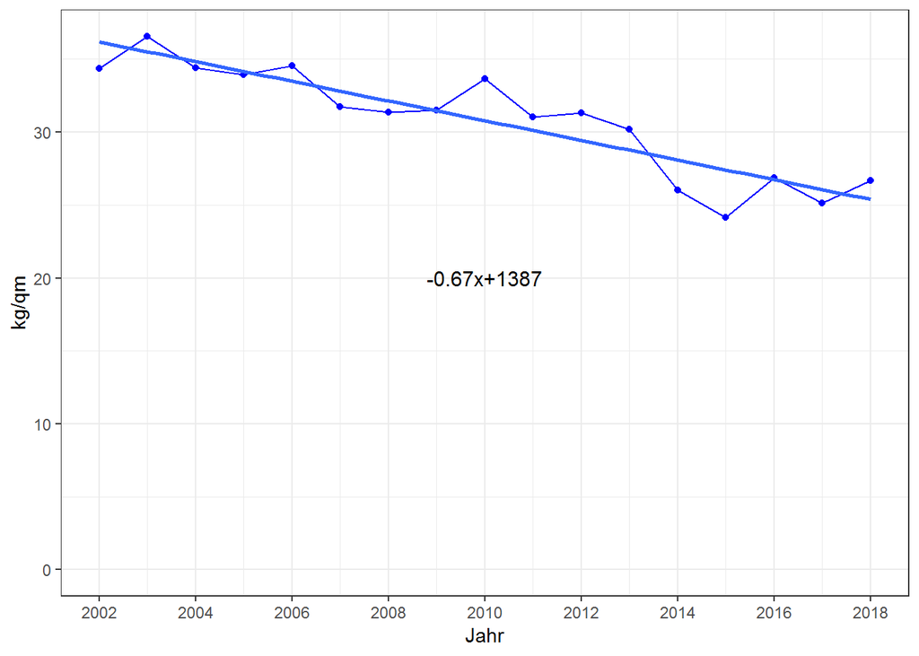

```r
points_line_lm(input_data = spez_co2_emission,
               xVar = "abrechnungsjahr",
               yVar = "spez_co2",
               ymin=0,
               ymax=max(spez_co2_emission$spez_co2),
               x_eq = 2010,
               y_eq = 20,
               size_eq = 4,
               plot_title = NULL,
               xlab = "Jahr",
               ylab = "kg/qm")
```

```r
i_subsubsection <- i_subsubsection + 1
```

### 1.2.2 Stadtbezirke, MFH + 1-2 FH, flächenbezogene co2 Emission aus der Beheizung von Wohnraum 2002-2018 in kg/m2 [AN]

*Or am I supposed to show the pictures of all the bezirke simultaneously?*

```r
berlin_co2_all
```

```
##    abrechnungsjahr charlottenburg_wilmersdorf friedrichshain_kreuzberg
## 1             2002                   437.5293                 297.2324
## 2             2003                   466.5623                 288.0173
## 3             2004                   523.9296                 267.8083
## 4             2005                   499.0712                 269.5375
## 5             2006                   506.4530                 287.4582
## 6             2007                   467.4310                 260.4179
## 7             2008                   471.6374                 257.8947
## 8             2009                   397.8959                 252.1482
## 9             2010                   497.1840                 300.9858
## 10            2011                   439.2849                 238.1180
## 11            2012                   463.8478                 260.7414
## 12            2013                   460.5407                 236.0173
## 13            2014                   338.4202                 191.1728
## 14            2015                   314.9513                 190.9628
```

[output cut: 57 more lines]

```r
bezirk_areas_all
```

```
##    abrechnungsjahr charlottenburg_wilmersdorf friedrichshain_kreuzberg
## 1             2002                   13030885                  8939285
## 2             2003                   13092050                  9018525
## 3             2004                   13153215                  9097765
## 4             2005                   13214381                  9177006
## 5             2006                   13275546                  9256246
## 6             2007                   13336712                  9335487
## 7             2008                   13397877                  9414727
## 8             2009                   13459043                  9493968
## 9             2010                   13546300                  9640400
## 10            2011                   13589400                  9671600
## 11            2012                   13627100                  9696100
## 12            2013                   13676600                  9747200
## 13            2014                   13758400                  9829000
## 14            2015                   13812200                  9980800
```

[output cut: 57 more lines]

```r
bezirke_spez_co2 <- 1e6*berlin_co2_all/bezirk_areas_all
bezirke_spez_co2$abrechnungsjahr <- 2002:2018
```

```r
bezirke_spez_co2
```

```
##    abrechnungsjahr charlottenburg_wilmersdorf friedrichshain_kreuzberg
## 1             2002                   33.57633                 33.25013
## 2             2003                   35.63707                 31.93619
## 3             2004                   39.83281                 29.43672
## 4             2005                   37.76728                 29.37096
## 5             2006                   38.14932                 31.05559
## 6             2007                   35.04844                 27.89548
## 7             2008                   35.20240                 27.39269
## 8             2009                   29.56346                 26.55878
## 9             2010                   36.70257                 31.22130
## 10            2011                   32.32556                 24.62033
## 11            2012                   34.03863                 26.89136
## 12            2013                   33.67363                 24.21386
## 13            2014                   24.59735                 19.44988
## 14            2015                   22.80240                 19.13302
```

[output cut: 57 more lines]

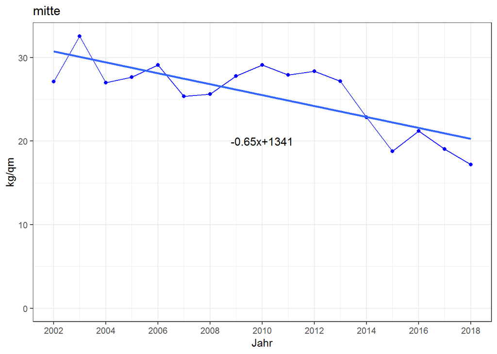

```r
bindex <- 5
points_line_lm(input_data = bezirke_spez_co2,
               xVar = "abrechnungsjahr",
               yVar = bezirk_list[bindex],
               ymin=0,
               ymax=max(bezirke_spez_co2[[bezirk_list[bindex]]]),
               x_eq = 2010,
               y_eq = 20,
               size_eq = 4,
               plot_title = bezirk_list[bindex],
               xlab = "Jahr",
               ylab = "kg/qm")
```

Extract the 2018 values from the above…

```r
bezirke_spez_co2_2018 <- bezirke_spez_co2[bezirke_spez_co2$abrechnungsjahr==2018 , ]
bezirke_spez_co2_2018
```

```
##    abrechnungsjahr charlottenburg_wilmersdorf friedrichshain_kreuzberg
## 17            2018                   23.49628                 24.71456
##    lichtenberg marzahn_hellersdorf    mitte neukoelln   pankow
## 17    21.92513            27.71826 17.19342  23.21158 24.86834
##    reinickendorf  spandau steglitz_zehlendorf tempelhof_schoeneberg
## 17      36.88289 35.81176            33.49101              29.46204
##    treptow_koepenick    total
## 17           24.7311 26.67217
```

```r
bezirke_spezco2_2018 <- as.data.frame(t(bezirke_spez_co2_2018))
bezirke_spezco2_2018$bezirk <- row.names(bezirke_spezco2_2018)
names(bezirke_spezco2_2018) <- c("wert","bezirk")
bezirke_spezco2_2018 <- bezirke_spezco2_2018[bezirke_spezco2_2018$bezirk!="abrechnungsjahr" , ]
bezirke_spezco2_2018
```

```
##                                wert                     bezirk
## charlottenburg_wilmersdorf 23.49628 charlottenburg_wilmersdorf
## friedrichshain_kreuzberg   24.71456   friedrichshain_kreuzberg
## lichtenberg                21.92513                lichtenberg
## marzahn_hellersdorf        27.71826        marzahn_hellersdorf
## mitte                      17.19342                      mitte
## neukoelln                  23.21158                  neukoelln
## pankow                     24.86834                     pankow
## reinickendorf              36.88289              reinickendorf
## spandau                    35.81176                    spandau
## steglitz_zehlendorf        33.49101        steglitz_zehlendorf
## tempelhof_schoeneberg      29.46204      tempelhof_schoeneberg
## treptow_koepenick          24.73110          treptow_koepenick
## total                      26.67217                      total
```

Here it makes more sense to put in the values of the linear trend…

```r
linearizer <- function(obj,dropCols,xVar) {
  obj_new <- obj[ , !(names(obj) %in% dropCols)]
  feature_list <- names(obj_new)[ !(names(obj_new) %in% c(dropCols,xVar)) ]
  storage <- list()
  for (feature in feature_list) {
    storage[[feature]] <- lm(get(feature) ~ get(xVar) , data = obj)
    obj_new[[feature]] <- as.numeric(predict(storage[[feature]] , newdata = obj))
  }
  return(obj_new)
}
```

```r
bezirke_spez_co2_linear <- linearizer(bezirke_spez_co2 , dropCols = NULL , xVar = "abrechnungsjahr")
```

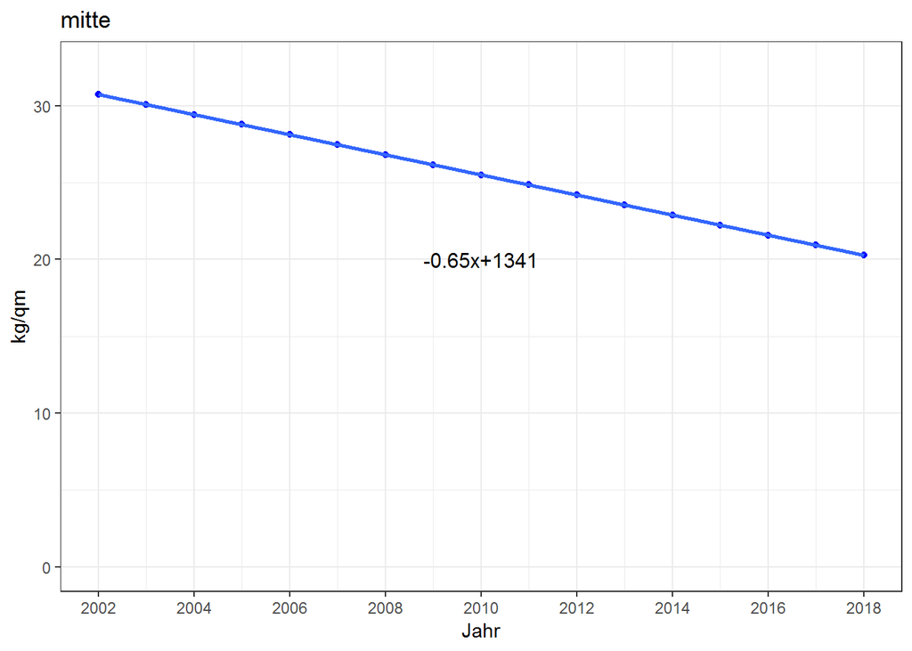

```r
bindex <- 5
points_line_lm(input_data = bezirke_spez_co2_linear,
               xVar = "abrechnungsjahr",
               yVar = bezirk_list[bindex],
               ymin=0,
               ymax=max(bezirke_spez_co2[[bezirk_list[bindex]]]),
               x_eq = 2010,
               y_eq = 20,
               size_eq = 4,
               plot_title = bezirk_list[bindex],
               xlab = "Jahr",
               ylab = "kg/qm")
```

```r
bezirke_spez_co2_linear_2018 <- bezirke_spez_co2_linear[bezirke_spez_co2_linear$abrechnungsjahr==2018 , ]
bezirke_spezco2_linear_2018 <- as.data.frame(t(bezirke_spez_co2_linear_2018))
bezirke_spezco2_linear_2018$bezirk <- row.names(bezirke_spezco2_linear_2018)
names(bezirke_spezco2_linear_2018) <- c("wert","bezirk")
bezirke_spezco2_linear_2018 <- bezirke_spezco2_linear_2018[bezirke_spezco2_linear_2018$bezirk!="abrechnungsjahr" , ]
bezirke_spezco2_linear_2018
```

```
##                                wert                     bezirk
## charlottenburg_wilmersdorf 24.10319 charlottenburg_wilmersdorf
## friedrichshain_kreuzberg   20.35541   friedrichshain_kreuzberg
## lichtenberg                20.03695                lichtenberg
## marzahn_hellersdorf        28.94024        marzahn_hellersdorf
## mitte                      20.27215                      mitte
## neukoelln                  24.81356                  neukoelln
## pankow                     21.05257                     pankow
## reinickendorf              34.32516              reinickendorf
## spandau                    30.62220                    spandau
## steglitz_zehlendorf        33.00652        steglitz_zehlendorf
## tempelhof_schoeneberg      26.73684      tempelhof_schoeneberg
## treptow_koepenick          23.20318          treptow_koepenick
## total                      25.39674                      total
```

Now make a bar plot of these.

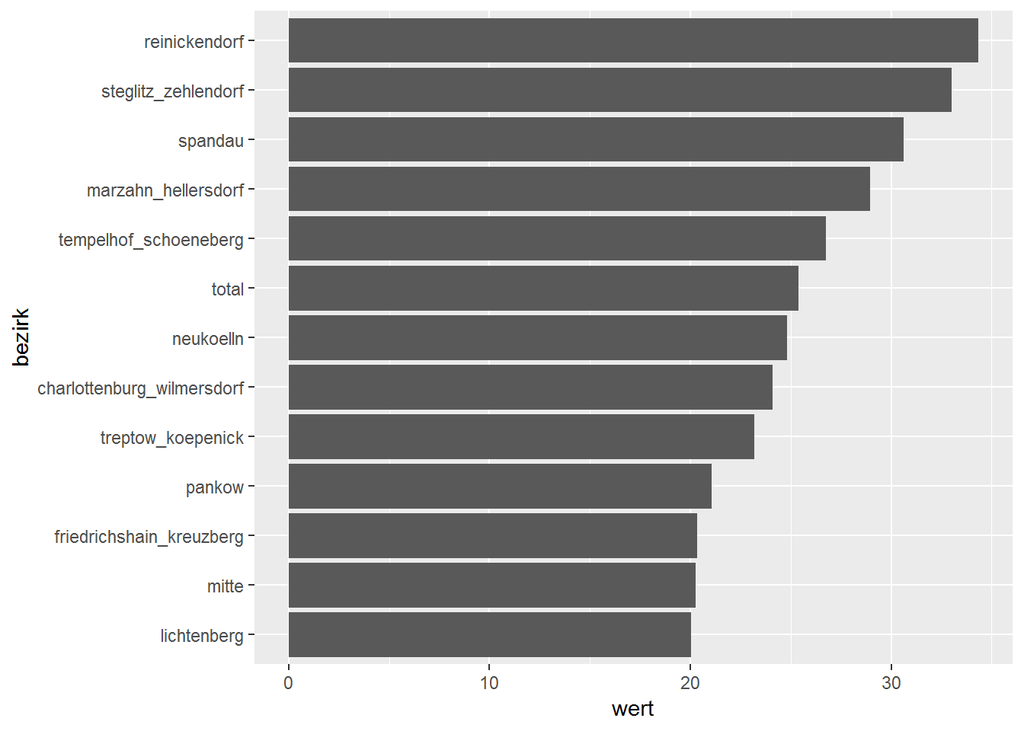

```r
 bezirke_spezco2_linear_2018$bezirk <- factor(
      bezirke_spezco2_linear_2018$bezirk ,
      levels = bezirke_spezco2_linear_2018$bezirk[order(bezirke_spezco2_linear_2018$wert)])
#barplot(bezirke_spezco2_linear_2018$wert)
ggplot(data=bezirke_spezco2_linear_2018,aes(x=bezirk,y=wert))+geom_bar(stat="identity")+coord_flip()
```

```r
i_subsubsection <- i_subsubsection + 1
```

### 1.2.3 Stadtbezirke, MFH + 1-2 FH, flächenbezogene co2 Emission aus der Beheizung von Wohnraum im Jahr 2018 in kg/m2 [AN]

```r
i_subsubsection <- i_subsubsection + 1
```

The per unit area co2 emission when the 2002 value is 100.

`spez_co2_emission` contains the berlin values of the specific co2 emission.

```r
spez_co2_emission
```

```
##    abrechnungsjahr spez_co2
## 1             2002 34.37184
## 2             2003 36.56125
## 3             2004 34.39632
## 4             2005 33.96149
## 5             2006 34.56152
## 6             2007 31.74543
## 7             2008 31.37412
## 8             2009 31.50442
## 9             2010 33.66437
## 10            2011 31.02535
## 11            2012 31.30158
## 12            2013 30.21521
## 13            2014 26.03424
## 14            2015 24.15518
## 15            2016 26.85315
## 16            2017 25.11814
## 17            2018 26.67217
```

```r
get2002as100 <- function(obj,dropCols) {
  isNotDropCol <- !(names(obj) %in% dropCols)
  for (xvar in names(obj)[isNotDropCol]) {
    obj[[xvar]] <- 100*obj[[xvar]]/obj[[xvar]][1]
  }
  return(obj)
}
```

```r
get2002as100(spez_co2_emission , "abrechnungsjahr")
```

```
##    abrechnungsjahr  spez_co2
## 1             2002 100.00000
## 2             2003 106.36977
## 3             2004 100.07121
## 4             2005  98.80616
## 5             2006 100.55185
## 6             2007  92.35885
## 7             2008  91.27855
## 8             2009  91.65764
## 9             2010  97.94172
## 10            2011  90.26386
## 11            2012  91.06752
## 12            2013  87.90689
## 13            2014  75.74294
## 14            2015  70.27608
## 15            2016  78.12543
## 16            2017  73.07767
## 17            2018  77.59889
```

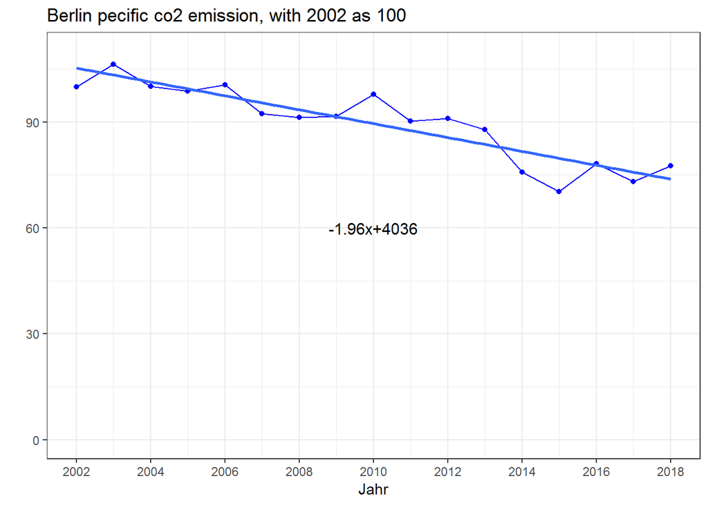

```r
points_line_lm(input_data = get2002as100(spez_co2_emission , "abrechnungsjahr"),
               xVar = "abrechnungsjahr",
               yVar = "spez_co2",
               ymin=0,
               ymax=110,
               x_eq = 2010,
               y_eq = 60,
               size_eq = 4,
               plot_title = "Berlin pecific co2 emission, with 2002 as 100",
               xlab = "Jahr",
               ylab = " ")
```

```r
i_subsubsection <- i_subsubsection + 1
```

### 1.2.5 Alle Stadtbezirke, alle Wohngebäude, flächenbezogene co2 Emission aus der Beheizung von Wohnraum, Entwicklung 2002-2018 und Niveau 2018 (Rang-folge)

```r
i_subsubsection <- i_subsubsection + 1
```

### 1.2.6 Berlin, alle Wohngebäude, durchschnittliche Emissionsminderung je qm Nutzfläche im Zeitraum 2002-2018

```r
i_subsection <- i_subsection + 1
```

## 1.3 Emission pro Einwohner

```r
i_subsubsection <- 1
```

### 1.3.1 Stadtbezirke, alle Wohngebäude, co2-Emission aus der Beheizung von Wohnraum pro Einwohner

```
bezirk_population <- read.csv2("D:/GITHUB_REPOS/co2emissions/Berlin/BezirkAnalysis/PopulationBezirke/BerlinBezirkPopulation.csv",stringsAsFactors = FALSE)
names(bezirk_population) <- c("bezirk",2002:2018)
#converting data from wide to long: http://www.cookbook-r.com/Manipulating_data/Converting_data_between_wide_and_long_format/
# look at the reshape2 option. id.vars has to be bezirk
require(reshape2)
bezirk_population <- melt(bezirk_population,id.vars = "bezirk")
#convert $variable and $value to numeric
bezirk_population$variable <- as.character(bezirk_population$variable)
bezirk_population$variable <- as.numeric(bezirk_population$variable)
bezirk_population$value <- gsub("\\.","",bezirk_population$value)
bezirk_population$value <- as.numeric(bezirk_population$value)
names(bezirk_population) <- c("bezirk","abrechnungsjahr","population")

bezirk_population$bezirk[ bezirk_population$bezirk=="Berlin-Mitte"] <- "mitte"
bezirk_population$bezirk[ bezirk_population$bezirk=="Charlottenburg Wilmersdorf"] <- "charlottenburg_wilmersdorf"
bezirk_population$bezirk[ bezirk_population$bezirk=="Friedrichshain - Kreuzberg"] <- "friedrichshain_kreuzberg"
bezirk_population$bezirk[ bezirk_population$bezirk=="Lichtenberg"] <- "lichtenberg"
bezirk_population$bezirk[ bezirk_population$bezirk=="Marzahn-Hellersdorf"] <- "marzahn_hellersdorf"
bezirk_population$bezirk[ bezirk_population$bezirk=="Neukölln"] <- "neukoelln"
bezirk_population$bezirk[ bezirk_population$bezirk=="Pankow"] <- "pankow"
bezirk_population$bezirk[ bezirk_population$bezirk=="Reinickendorf"] <- "reinickendorf"
bezirk_population$bezirk[ bezirk_population$bezirk=="Spandau"] <- "spandau"
bezirk_population$bezirk[ bezirk_population$bezirk=="Steglitz Zehlendorf"] <- "steglitz_zehlendorf"
bezirk_population$bezirk[ bezirk_population$bezirk=="Tempelhof-Schöneberg"] <- "tempelhof_schoeneberg"
bezirk_population$bezirk[ bezirk_population$bezirk=="Treptow-Köpenick"] <- "treptow_koepenick"
bezirk_population
dcast(bezirk_population , abrechnungsjahr~bezirk,value.var = "population")
```

from: Johannes Hengstenberg johanneshengstenberg@gmail.com to: Bhaskar Kamble kbhaskar.iitk@gmail.com date: Jun 17, 2019, 7:46 PM subject: Population Data for the Bezirke

from: Johannes Hengstenberg johanneshengstenberg@gmail.com to: Bhaskar Kamble kbhaskar.iitk@gmail.com date: Jun 16, 2019, 3:09 PM subject: Population of Berlin

Now you know the population, so can find per capita co2 emissions.

```r
source("D:/GITHUB_REPOS/co2emissions/Berlin/BezirkAnalysis/getBerlinBezirkPopulation.R")
bezirk_population <- getBerlinBezirkPopulation()
#bezirk_population
```

```r
bezirk_population <- getRowSums(bezirk_population , dropCols = "abrechnungsjahr")
bezirk_population
```

```
##    abrechnungsjahr charlottenburg_wilmersdorf friedrichshain_kreuzberg
## 1             2002                     308961                   249615
## 2             2003                     308946                   251006
## 3             2004                     309041                   252619
## 4             2005                     309157                   255205
## 5             2006                     309538                   257802
## 6             2007                     310281                   259381
## 7             2008                     310969                   260563
## 8             2009                     312067                   261821
## 9             2010                     313912                   263628
## 10            2011                     316333                   265881
## 11            2012                     319153                   269026
## 12            2013                     322778                   272487
## 13            2014                     327046                   275679
## 14            2015                     330954                   278580
```

[output cut: 57 more lines]

```r
berlin_co2_percapita <- 1e6*berlin_co2_all$total / bezirk_population$total
#bezirk_co2_percapita$abrechnungsjahr <- 2002:2018
berlin_co2_percapita <- data.frame( abrechnungsjahr = 2002:2018 , co2_percapita = berlin_co2_percapita)
berlin_co2_percapita
```

```
##    abrechnungsjahr co2_percapita
## 1             2002     1290.1621
## 2             2003     1380.8363
## 3             2004     1306.5680
## 4             2005     1297.1615
## 5             2006     1326.1114
## 6             2007     1223.2912
## 7             2008     1213.2947
## 8             2009     1220.4553
## 9             2010     1307.7297
## 10            2011     1198.5932
## 11            2012     1201.2689
## 12            2013     1150.5135
## 13            2014      984.1460
## 14            2015      907.5403
## 15            2016     1004.2682
## 16            2017      940.4804
## 17            2018      995.2671
```

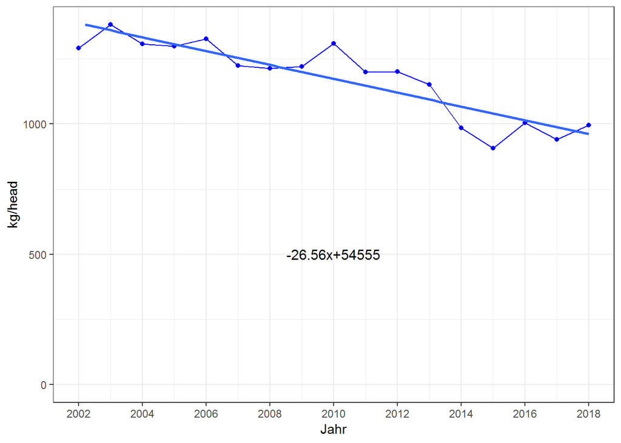

```r
points_line_lm(input_data = berlin_co2_percapita,
               xVar = "abrechnungsjahr",
               yVar = "co2_percapita",
               ymin=0,
               ymax=max(berlin_co2_percapita$co2_percapita),
               x_eq = 2010,
               y_eq = 500,
               size_eq = 4,
               plot_title = NULL,
               xlab = "Jahr",
               ylab = "kg/head")
```

```r
i_subsubsection <- i_subsubsection + 1
```

### 1.3.2 Stadtbezirke, alle Wohngebäude, co2-Emission pro Einwohner aus der Beheizung von Wohnraum, 2002-2018, 2002=100

```r
berlin_co2_percapita_2002as100 <- get2002as100(berlin_co2_percapita , "abrechnungsjahr")
```

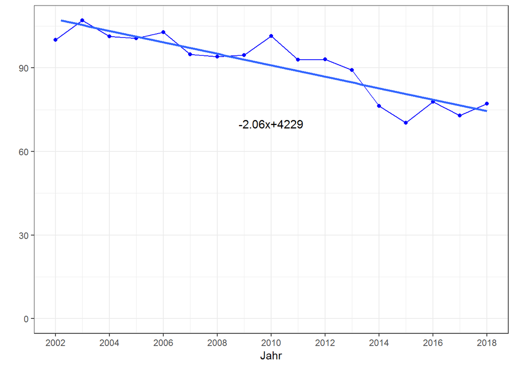

```r
points_line_lm(input_data = berlin_co2_percapita_2002as100,
               xVar = "abrechnungsjahr",
               yVar = "co2_percapita",
               ymin=0,
               ymax=max(berlin_co2_percapita_2002as100$co2_percapita),
               x_eq = 2010,
               y_eq = 70,
               size_eq = 4,
               plot_title = NULL,
               xlab = "Jahr",
               ylab = " ")
```

```r
i_subsubsection <- i_subsubsection + 1
```

- Looks like a bar plot is needed here

```r
bezirk_co2_percapita <- 1e6*berlin_co2_all/bezirk_population
bezirk_co2_percapita$abrechnungsjahr <- 2002:2018
bezirk_co2_percapita
```

```
##    abrechnungsjahr charlottenburg_wilmersdorf friedrichshain_kreuzberg
## 1             2002                  1416.1312                1190.7632
## 2             2003                  1510.1742                1147.4519
## 3             2004                  1695.3400                1060.1274
## 4             2005                  1614.2970                1056.1606
## 5             2006                  1636.1579                1115.0346
## 6             2007                  1506.4764                1003.9977
## 7             2008                  1516.6701                 989.7595
## 8             2009                  1275.0335                 963.0555
## 9             2010                  1583.8325                1141.7066
## 10            2011                  1388.6788                 895.5810
## 11            2012                  1453.3711                 969.2051
## 12            2013                  1426.8033                 866.1600
## 13            2014                  1034.7786                 693.4618
## 14            2015                   951.6466                 685.4866
```

[output cut: 57 more lines]

```r
bezirk_co2_percapita_linear <- linearizer(bezirk_co2_percapita,dropCols = NULL , xVar = "abrechnungsjahr")
bezirk_co2_percapita_linear
```

```
##    abrechnungsjahr charlottenburg_wilmersdorf friedrichshain_kreuzberg
## 1             2002                   1692.223                1169.5428
## 2             2003                   1649.582                1142.1740
## 3             2004                   1606.941                1114.8053
## 4             2005                   1564.301                1087.4365
## 5             2006                   1521.660                1060.0677
## 6             2007                   1479.020                1032.6990
## 7             2008                   1436.379                1005.3302
## 8             2009                   1393.739                 977.9614
## 9             2010                   1351.098                 950.5927
## 10            2011                   1308.458                 923.2239
## 11            2012                   1265.817                 895.8551
## 12            2013                   1223.177                 868.4864
## 13            2014                   1180.536                 841.1176
## 14            2015                   1137.895                 813.7488
```

[output cut: 57 more lines]

- Just for the sake, I can plot for a specific bezirk here…later do it with plotly interactively.

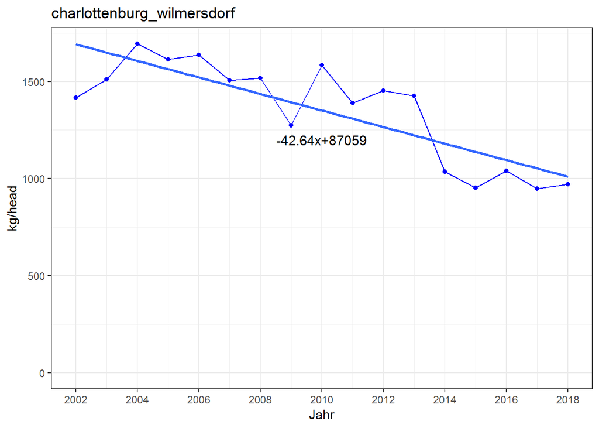

```r
bindex <- 1
points_line_lm(input_data = bezirk_co2_percapita,
               xVar = "abrechnungsjahr",
               yVar = bezirk_list[bindex],
               ymin=0,
               ymax=max(bezirk_co2_percapita[[bezirk_list[bindex]]]),
               x_eq = 2010,
               y_eq = 1200,
               size_eq = 4,
               plot_title = bezirk_list[bindex],
               xlab = "Jahr",
               ylab = "kg/head")
```

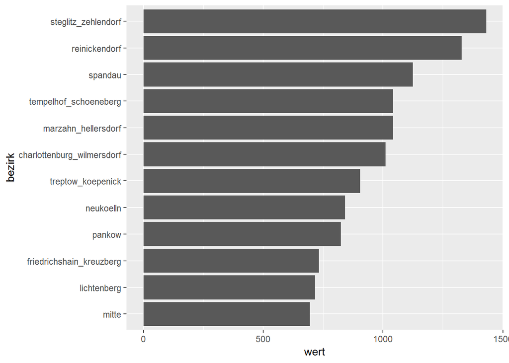

```r
bezirk_co2_percapita_linear_2018 <- bezirk_co2_percapita_linear[bezirk_co2_percapita_linear$abrechnungsjahr==2018 , ]
bezirk_co2_percapita_linear_2018 <- as.data.frame(t(bezirk_co2_percapita_linear_2018))
bezirk_co2_percapita_linear_2018$bezirk <- row.names(bezirk_co2_percapita_linear_2018)
names(bezirk_co2_percapita_linear_2018) <- c("wert","bezirk")
bezirk_co2_percapita_linear_2018 <- bezirk_co2_percapita_linear_2018[bezirk_co2_percapita_linear_2018$bezirk!="abrechnungsjahr" , ]
bezirk_co2_percapita_linear_2018 <- bezirk_co2_percapita_linear_2018[bezirk_co2_percapita_linear_2018$bezirk!="total" , ]
#bezirk_co2_percapita_linear_2018

bezirk_co2_percapita_linear_2018$bezirk <- factor(
      bezirk_co2_percapita_linear_2018$bezirk ,
      levels = bezirk_co2_percapita_linear_2018$bezirk[order(bezirk_co2_percapita_linear_2018$wert)])
ggplot(data=bezirk_co2_percapita_linear_2018,aes(x=bezirk,y=wert))+geom_bar(stat="identity")+coord_flip()
```

```r
i_subsubsection <- i_subsubsection + 1
```

### 1.3.4 Stadtbezirke, alle Wohngebäude, co2-Emission aus der Beheizung von Wohnraum pro Einwohner, Veränderung 2002/2018 in Prozent

- change with respect to previous year? i.e. 100 * [ x(i+1) - x(i) ]/ x(i) ? (i denotes the year here)

```r
i_subsection <- i_subsection + 1
```

## 1.4 Prognose

- Do the x + I(x^2) analysis.

```r
i_subsubsection <- 1
```

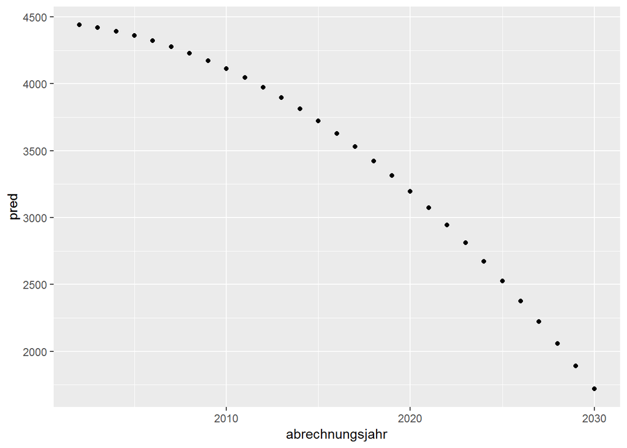

```r
#berlin_co2_all
quadmodel <- lm(total~abrechnungsjahr+I(abrechnungsjahr^2),data=berlin_co2_all)
from2002_till_2030 <- data.frame(abrechnungsjahr=2002:2030)
prognose <- data.frame(abrechnungsjahr = 2002:2030 , pred = as.numeric(predict(quadmodel,newdata=from2002_till_2030)))
ggplot(prognose , aes(x=abrechnungsjahr , y = pred))+geom_point()
```

```r
i_subsection <- i_subsection + 1
```

## 1.5 Diskussion

```r
i_section <- i_section+1
i_subsection <- 1
i_subsubsection <- 1
```

# 2. Alle Stadtbezirke, co2-emission aus Beheizung, 1-2 Familiengebäude

## 2.1 Absolute Zahlen

### 2.1.1 Berlin, 1-2 Familiengebäude, co2-Emission aus der Beheizung von Wohnraum 2002-2018 in 1.000 t

```r
alle_bezirke_co2$sfh
```

```
##    abrechnungsjahr charlottenburg_wilmersdorf friedrichshain_kreuzberg
## 1             2002                   38.09742                2.6420502
## 2             2003                   37.80490                2.7574057
## 3             2004                   36.55557                2.3157077
## 4             2005                   34.80975                2.1676129
## 5             2006                   35.52038                2.2005804
## 6             2007                   34.61589                1.8013261
## 7             2008                   33.81660                1.7387840
## 8             2009                   30.81899                1.5790129
## 9             2010                   30.76203                1.3024370
## 10            2011                   33.24231                1.8863541
## 11            2012                   30.61746                1.3811595
## 12            2013                   27.84803                1.5588895
## 13            2014                   26.35995                0.8894664
## 14            2015                   26.40115                1.0898912
```

[output cut: 57 more lines]

```r
berlin_co2_sfh <- getRowSums(alle_bezirke_co2$sfh , dropCols = "abrechnungsjahr")
berlin_co2_sfh
```

```
##    abrechnungsjahr charlottenburg_wilmersdorf friedrichshain_kreuzberg
## 1             2002                   38.09742                2.6420502
## 2             2003                   37.80490                2.7574057
## 3             2004                   36.55557                2.3157077
## 4             2005                   34.80975                2.1676129
## 5             2006                   35.52038                2.2005804
## 6             2007                   34.61589                1.8013261
## 7             2008                   33.81660                1.7387840
## 8             2009                   30.81899                1.5790129
## 9             2010                   30.76203                1.3024370
## 10            2011                   33.24231                1.8863541
## 11            2012                   30.61746                1.3811595
## 12            2013                   27.84803                1.5588895
## 13            2014                   26.35995                0.8894664
## 14            2015                   26.40115                1.0898912
```

[output cut: 57 more lines]

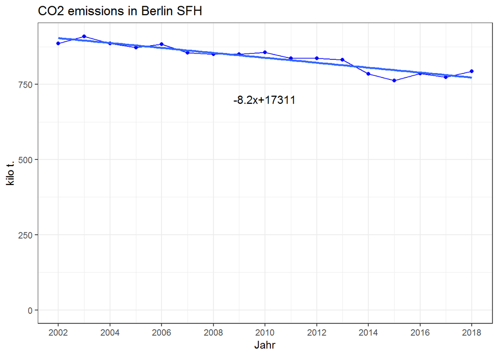

```r
points_line_lm(input_data = berlin_co2_sfh,
               xVar = "abrechnungsjahr",
               yVar = "total",
               ymin = 0,
               ymax = max(berlin_co2_sfh$total),
               x_eq = 2010,
               y_eq = 700,
               size_eq = 4,
               plot_title = "CO2 emissions in Berlin SFH",
               xlab = "Jahr",
               ylab = "kilo t.")
```

- Now split by ET

```r
co2_sfh_allebezirke_byET <- co2_allebezirke_byET$sfh
co2_sfh_allebezirke_byET
```

```
##    abrechnungsjahr   erdgas   waerme fluessiggas  heizoel holzpellets
## 1             2002 320.9928 3.542946    0.000000 533.4710  0.00000000
## 2             2003 288.7111 5.133224    0.000000 587.7168  0.00000000
## 3             2004 293.6147 5.557091    1.294382 557.8058  0.00000000
## 4             2005 336.6383 6.331517    4.772830 496.4423  0.00000000
## 5             2006 341.9268 4.810459    5.423371 503.0885  0.00000000
## 6             2007 325.0396 5.030013    3.481267 493.1154  0.00000000
## 7             2008 358.6379 4.556824    5.637400 452.4517  0.11328082
## 8             2009 375.8390 5.708403    4.265570 435.8945  0.38321201
## 9             2010 352.8829 5.229627    5.043785 471.1952  0.28678993
## 10            2011 326.2533 6.160202    2.308130 484.7856  0.08716954
## 11            2012 307.3344 4.142617    3.783370 500.4167  0.62720918
## 12            2013 316.6940 6.655070    3.911524 482.0715  0.54576652
## 13            2014 316.1633 3.764043   10.428462 438.7797  0.32888674
## 14            2015 326.3678 7.899303    9.235242 397.7130  1.17639896
```

[output cut: 21 more lines]

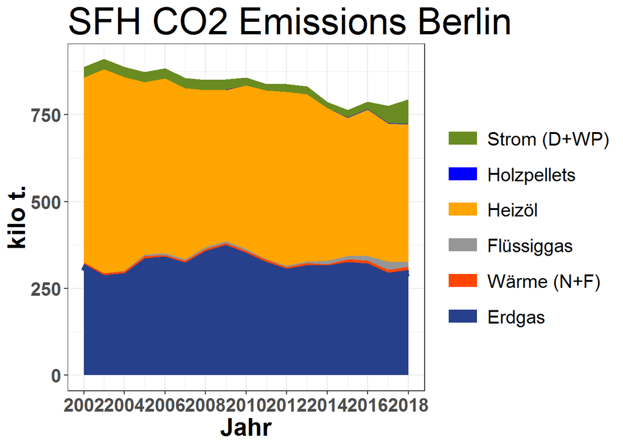

```r
co2_sfh_allebezirke_byET_cumsums <- getCumSums(obj=co2_sfh_allebezirke_byET , dropCols=c("abrechnungsjahr","total"))
#co2_all_allebezirke_byET_cumsums
plot_byET(co2_sfh_allebezirke_byET_cumsums , xlabel = "Jahr" , ylabel = "kilo t." , plottitle = "SFH CO2 Emissions Berlin")
```

```r
i_subsubsection <- i_subsubsection+1
```

### 2.1.2 Stadtbezirke, 1-2 Familiengebäude, co2-emissionen aus der Beheizung von Wohnraum 2002-2018 summiert in 1.000 t

- Here co2 emissions split by the bezirke

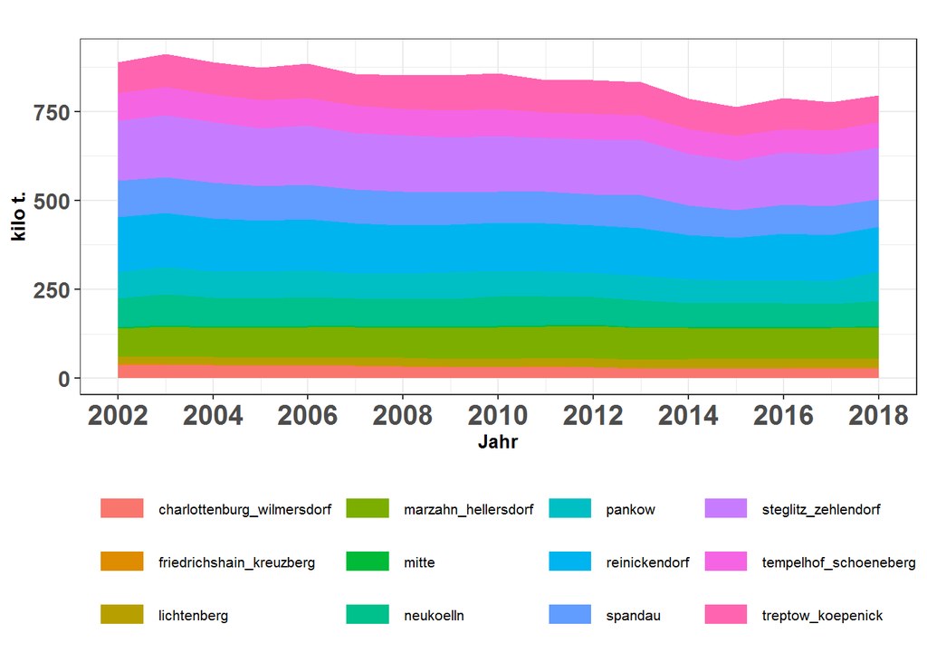

```r
berlin_co2_sfh_cumsums <- getCumSums(obj=berlin_co2_sfh , dropCols=c("abrechnungsjahr","total"))
plot_byBezirke(berlin_co2_sfh_cumsums , xlabel = "Jahr" , ylabel = "kilo t." , plottitle="")
```

```r
i_subsubsection <- i_subsubsection+1
```

### 2.1.3 Stadtbezirke, 1-2 Familiengebäude, co2-emissionen aus der Beheizung von Wohnraum 2002-2018 in Prozent

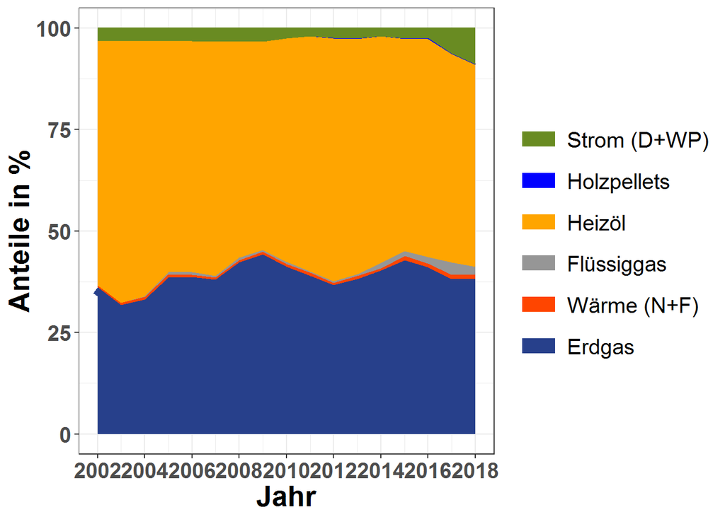

```r
co2_sfh_allebezirke_byET_prop <- find_proportions(co2_sfh_allebezirke_byET , drop_cols = c("abrechnungsjahr","total"))
co2_sfh_allebezirke_byET_prop_cumsums <- getCumSums(obj=co2_sfh_allebezirke_byET_prop , dropCols = "abrechnungsjahr")
plot_byET(co2_sfh_allebezirke_byET_prop_cumsums,xlabel = "Jahr" , ylabel = "Anteile in %" , plottitle = NULL)
```

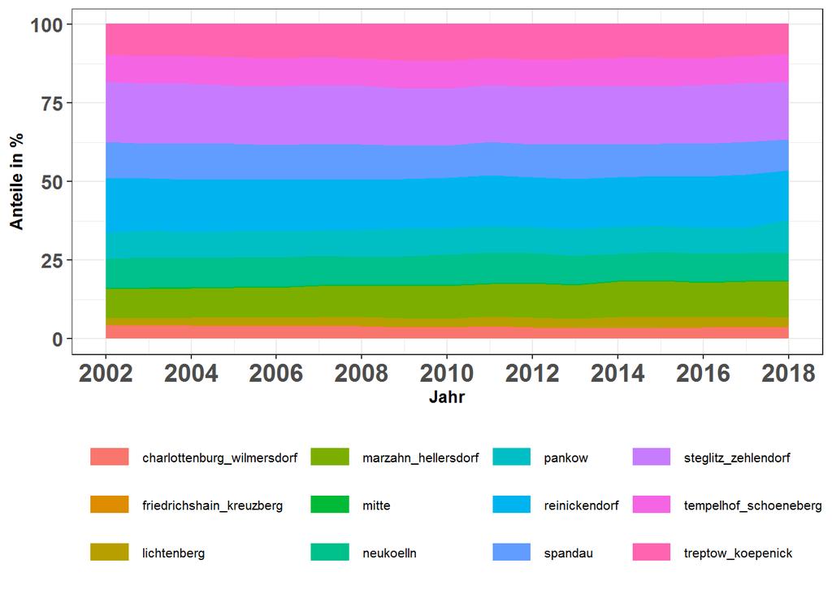

```r
berlin_co2_sfh_prop <- find_proportions(berlin_co2_sfh,drop_cols=c("abrechnungsjahr","total"))
berlin_co2_sfh_prop_cumsums <- getCumSums(berlin_co2_sfh_prop,dropCols="abrechnungsjahr")
plot_byBezirke(berlin_co2_sfh_prop_cumsums,xlabel = "Jahr" , ylabel = "Anteile in %" , plottitle = NULL)
```

```r
i_subsubsection <- i_subsubsection+1
```

### 2.1.4 Stadtbezirke, 1-2 Familiengebäude, co2-emissionen aus der Beheizung von Wohnraum 2002-2018 in 1.000 t

- same as 2.1.2

```r
i_subsubsection <- i_subsubsection+1
```

### 2.1.5 Stadtbezirke, 1-2 Familiengebäude, co2-emissionen aus der Beheizung von Wohnraum 2002-2018, Veränderung in Prozent

- Pending

```r
i_subsubsection <- i_subsubsection+1
```

### 2.1.6 Stadtbezirke, 1-2 Familiengebäude, Veränderung der co2-emissionen aus der Beheizung von Wohnraum 2002-2018 in Prozent

- Pending

```r
i_subsubsection <- 1
i_subsection <- i_subsection+1
```

## 2.2. Flächenbezug

### 2.2.1 Berlin, 1-2 Familiengebäude, flächenbezogene CO2-Emission aus der Beheizung von Wohnraum 2002 - 2018 in kg/m2[AN]

```r
bezirk_areas_sfh$abrechnungsjahr <- 2002:2018
bezirk_areas_sfh
```

```
##    abrechnungsjahr charlottenburg_wilmersdorf friedrichshain_kreuzberg
## 1             2002                   724536.9                 50538.10
## 2             2003                   733050.0                 50950.00
## 3             2004                   741563.1                 51361.90
## 4             2005                   750076.2                 51773.81
## 5             2006                   758589.3                 52185.71
## 6             2007                   767102.4                 52597.62
## 7             2008                   775615.5                 53009.52
## 8             2009                   784128.6                 53421.43
## 9             2010                   789600.0                 53500.00
## 10            2011                   800500.0                 53800.00
## 11            2012                   807600.0                 54200.00
## 12            2013                   820500.0                 56100.00
## 13            2014                   833900.0                 56700.00
## 14            2015                   838800.0                 55900.00
```

[output cut: 57 more lines]

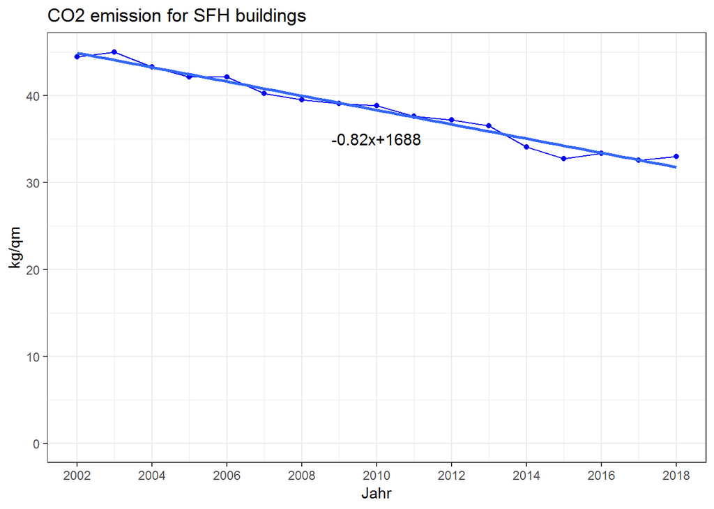

```r
spz_co2_sfh <- 1e6*berlin_co2_sfh$total/bezirk_areas_sfh$total
spez_co2_sfh <- data.frame(abrechnungsjahr=2002:2018 , spez_co2 = spz_co2_sfh )

points_line_lm(input_data = spez_co2_sfh,
               xVar = "abrechnungsjahr",
               yVar = "spez_co2",
               ymin=0,
               ymax=max(spez_co2_sfh$spez_co2),
               x_eq = 2010,
               y_eq = 35,
               size_eq = 4,
               plot_title = "CO2 emission for SFH buildings",
               xlab = "Jahr",
               ylab = "kg/qm")
```

```r
i_subsubsection <- i_subsubsection+1
```

```r
bezirke_spez_co2_sfh <- 1e6*berlin_co2_sfh/bezirk_areas_sfh
bezirke_spez_co2_sfh$abrechnungsjahr <- 2002:2018
```

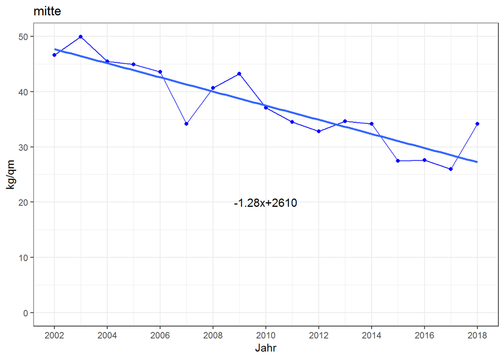

```r
bindex <- 5
points_line_lm(input_data = bezirke_spez_co2_sfh,
               xVar = "abrechnungsjahr",
               yVar = bezirk_list[bindex],
               ymin=0,
               ymax=max(bezirke_spez_co2_sfh[[bezirk_list[bindex]]]),
               x_eq = 2010,
               y_eq = 20,
               size_eq = 4,
               plot_title = bezirk_list[bindex],
               xlab = "Jahr",
               ylab = "kg/qm")
```

```r
i_subsubsection <- i_subsubsection+1
```

### 2.2.3. Stadtbezirke, 1-2 Familiengebäude, flächenbezogene CO2-Emission aus der Beheizung von Wohnraum im Jahr 2018 in kg/m2[AN]

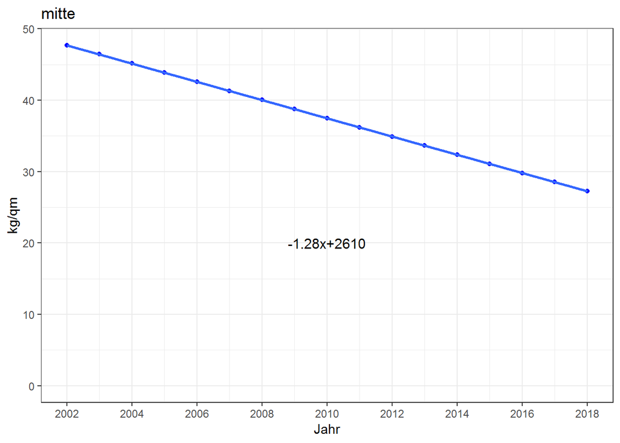

```r
bezirke_spez_co2_sfh_linear <- linearizer(bezirke_spez_co2_sfh , dropCols = NULL , xVar = "abrechnungsjahr")
bindex <- 5
points_line_lm(input_data = bezirke_spez_co2_sfh_linear,
               xVar = "abrechnungsjahr",
               yVar = bezirk_list[bindex],
               ymin=0,
               ymax=max(bezirke_spez_co2_sfh_linear[[bezirk_list[bindex]]]),
               x_eq = 2010,
               y_eq = 20,
               size_eq = 4,
               plot_title = bezirk_list[bindex],
               xlab = "Jahr",
               ylab = "kg/qm")
```

```r
bezirke_spez_co2_sfh_linear_2018 <- bezirke_spez_co2_sfh_linear[bezirke_spez_co2_sfh_linear$abrechnungsjahr==2018 , ]
bezirke_spezco2_sfh_linear_2018 <- as.data.frame(t(bezirke_spez_co2_sfh_linear_2018))
bezirke_spezco2_sfh_linear_2018$bezirk <- row.names(bezirke_spezco2_sfh_linear_2018)
names(bezirke_spezco2_sfh_linear_2018) <- c("wert","bezirk")
bezirke_spezco2_sfh_linear_2018 <- bezirke_spezco2_sfh_linear_2018[bezirke_spezco2_sfh_linear_2018$bezirk!="abrechnungsjahr" , ]
bezirke_spezco2_sfh_linear_2018 <- bezirke_spezco2_sfh_linear_2018[bezirke_spezco2_sfh_linear_2018$bezirk!="total" , ]
bezirke_spezco2_sfh_linear_2018
```

```
##                                wert                     bezirk
## charlottenburg_wilmersdorf 29.88073 charlottenburg_wilmersdorf
## friedrichshain_kreuzberg   16.95070   friedrichshain_kreuzberg
## lichtenberg                24.37576                lichtenberg
## marzahn_hellersdorf        30.57223        marzahn_hellersdorf
## mitte                      27.24539                      mitte
## neukoelln                  33.33331                  neukoelln
## pankow                     26.08267                     pankow
## reinickendorf              36.28970              reinickendorf
## spandau                    32.08602                    spandau
## steglitz_zehlendorf        35.45359        steglitz_zehlendorf
## tempelhof_schoeneberg      36.03124      tempelhof_schoeneberg
## treptow_koepenick          27.22228          treptow_koepenick
```

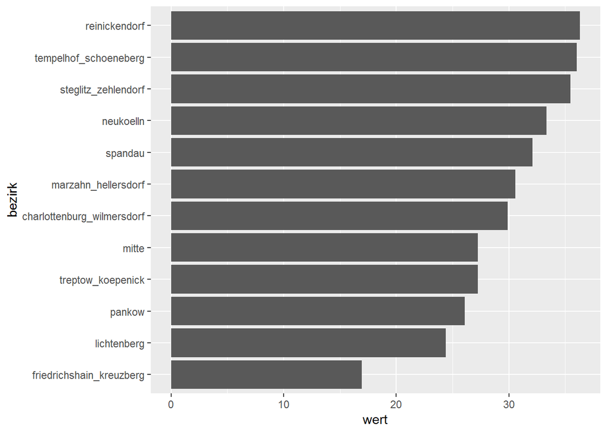

```r
bezirke_spezco2_sfh_linear_2018$bezirk <- factor(
      bezirke_spezco2_sfh_linear_2018$bezirk ,
      levels = bezirke_spezco2_sfh_linear_2018$bezirk[order(bezirke_spezco2_sfh_linear_2018$wert)])
#barplot(bezirke_spezco2_linear_2018$wert)
ggplot(data=bezirke_spezco2_sfh_linear_2018,aes(x=bezirk,y=wert))+geom_bar(stat="identity")+coord_flip()
```

```r
i_subsubsection <- i_subsubsection+1
```

```r
get2002as100(spez_co2_sfh , "abrechnungsjahr")
```

```
##    abrechnungsjahr  spez_co2
## 1             2002 100.00000
## 2             2003 101.35284
## 3             2004  97.51855
## 4             2005  94.77911
## 5             2006  94.80581
## 6             2007  90.62866
## 7             2008  88.99346
## 8             2009  88.01408
## 9             2010  87.48848
## 10            2011  84.72856
## 11            2012  83.70303
## 12            2013  82.18812
## 13            2014  76.68691
## 14            2015  73.63240
## 15            2016  75.09161
## 16            2017  73.28948
## 17            2018  74.28556
```

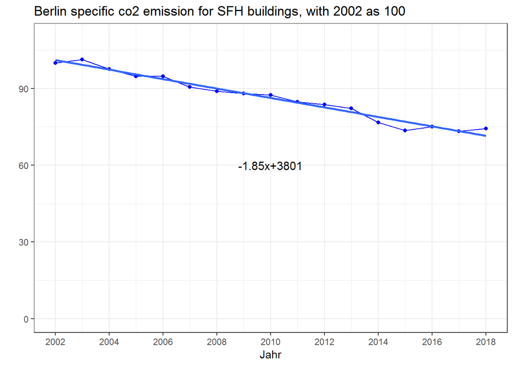

```r
points_line_lm(input_data = get2002as100(spez_co2_sfh , "abrechnungsjahr"),
               xVar = "abrechnungsjahr",
               yVar = "spez_co2",
               ymin=0,
               ymax=110,
               x_eq = 2010,
               y_eq = 60,
               size_eq = 4,
               plot_title = "Berlin specific co2 emission for SFH buildings, with 2002 as 100",
               xlab = "Jahr",
               ylab = " ")
```

```r
i_subsubsection <- i_subsubsection+1
```

### 2.2.5. Alle Stadtbezirke, 1-2 Familiengebäude, flächenbezogene CO2-Emission aus der Beheizung von Wohnraum, Entwicklung 2002 - 2018 und Niveau 2018 (Rang¬folge)

```r
i_subsubsection <- i_subsubsection+1
```

### 2.2.6. Berlin, 1-2 Familiengebäude, durchschnittliche Emissionsminderung je qm Nutzfläche im Zeitraum 2012 - 2018

```r
i_subsection <- i_subsection + 1
```

## 2.3. Emission pro Einwohner

```r
i_subsubsection <- 1
```

### 2.3.1. Stadtbezirke, 1-2 Familiengebäude, CO2-Emission aus der Beheizung von Wohnraum pro Einwohner

**I need the data for the population in SFH and MFH buildings**

```r
i_subsubsection <- i_subsubsection+1
```

### 2.3.2. Stadtbezirke, 1-2 Familiengebäude, CO2-Emission pro Einwohner aus der Beheizung von Wohnraum, 2002 – 2008, 2002 = 100

**I need the data for the population in SFH and MFH buildings**

```r
i_subsubsection <- i_subsubsection+1
```

### 2.3.3. Stadtbezirke, 1-2 Familiengebäude, CO2-Emissionen aus der Beheizung von Wohnraum pro Einwohner, Niveau im Jahr 2018 in t/Einwohner

**I need the data for the population in SFH and MFH buildings**

```r
i_subsubsection <- i_subsubsection+1
```

### 2.3.4. Stadtbezirke, 1-2 Familiengebäude, CO2-Emissionen aus der Beheizung von Wohnraum pro Einwohner, Veränderung 2002 / 2018 in Prozent

**I need the data for the population in SFH and MFH buildings**

```r
i_subsection <- i_subsection+1
```

## 2.4. Prognose

```r
i_subsubsection <- 1
```

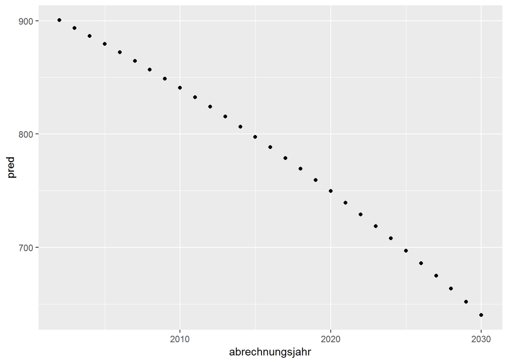

```r
quadmodel_sfh <- lm(total~abrechnungsjahr+I(abrechnungsjahr^2),data=berlin_co2_sfh)
from2002_till_2030 <- data.frame(abrechnungsjahr=2002:2030)
prognose_sfh <- data.frame(abrechnungsjahr = 2002:2030 , pred = as.numeric(predict(quadmodel_sfh,newdata=from2002_till_2030)))
ggplot(prognose_sfh , aes(x=abrechnungsjahr , y = pred))+geom_point()
```

```r
i_subsection <- i_subsection + 1
```

## 2.5. Diskussion

```r
i_section <- i_section + 1
```

# 3. Alle Stadtbezirke, CO2-Emission aus Beheizung, Mehrfamiliengebäude

```r
i_subsection <- 1
```

## 3.1. Absolute Zahlen

```r
i_subsubsection <- 1
```

### 3.1.1. Berlin, Mehrfamiliengebäude, CO2-Emission aus der Beheizung von Wohnraum 2002 - 2018 in 1.000 t

```r
berlin_co2_mfh <- getRowSums(alle_bezirke_co2$mfh , dropCols = "abrechnungsjahr")
berlin_co2_mfh
```

```
##    abrechnungsjahr charlottenburg_wilmersdorf friedrichshain_kreuzberg
## 1             2002                   399.4319                 294.5903
## 2             2003                   428.7574                 285.2599
## 3             2004                   487.3740                 265.4926
## 4             2005                   464.2615                 267.3698
## 5             2006                   470.9326                 285.2576
## 6             2007                   432.8151                 258.6166
## 7             2008                   437.8208                 256.1559
## 8             2009                   367.0769                 250.5691
## 9             2010                   466.4220                 299.6834
## 10            2011                   406.0426                 236.2316
## 11            2012                   433.2303                 259.3602
## 12            2013                   432.6927                 234.4584
## 13            2014                   312.0602                 190.2834
## 14            2015                   288.5501                 189.8730
```

[output cut: 57 more lines]

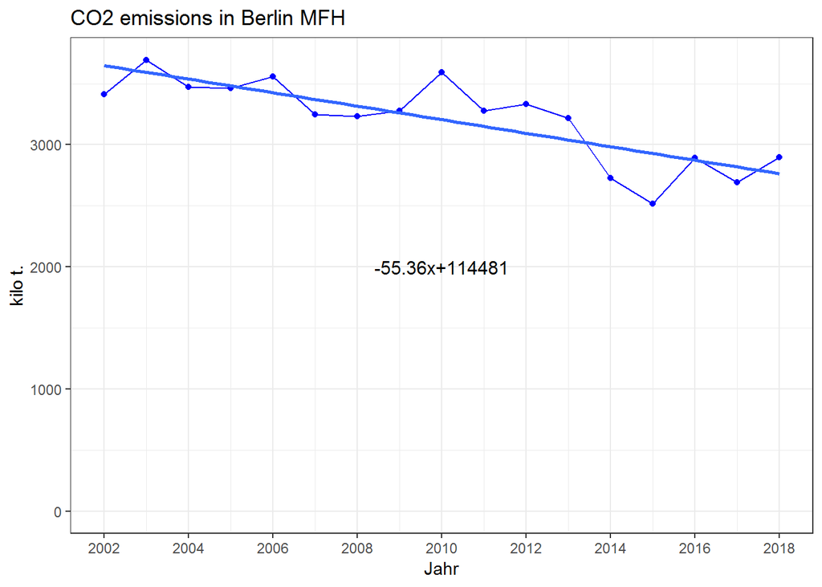

```r
points_line_lm(input_data = berlin_co2_mfh,
               xVar = "abrechnungsjahr",
               yVar = "total",
               ymin = 0,
               ymax = max(berlin_co2_mfh$total),
               x_eq = 2010,
               y_eq = 2000,
               size_eq = 4,
               plot_title = "CO2 emissions in Berlin MFH",
               xlab = "Jahr",
               ylab = "kilo t.")
```

- Now split by ET

```r
co2_mfh_allebezirke_byET <- co2_allebezirke_byET$mfh
co2_mfh_allebezirke_byET
```

```
##    abrechnungsjahr   erdgas   waerme fluessiggas   heizoel holzpellets
## 1             2002 1425.313 437.1350   0.0000000 1501.3892  0.00000000
## 2             2003 1219.068 351.7543   0.0000000 2073.8530  0.00000000
## 3             2004 1169.550 344.0184   0.6333009 1909.7609  0.00000000
## 4             2005 1359.731 325.0214   2.9657339 1723.4576  0.04967672
## 5             2006 1517.858 319.2860   3.1605813 1665.1732  0.05636583
## 6             2007 1328.905 324.6698   0.2929358 1544.9283  0.05977333
## 7             2008 1289.191 341.7451  17.5996834 1533.6597  0.07157690
## 8             2009 1418.327 427.7833  15.3941549 1363.1877  0.08886308
## 9             2010 1227.913 453.7213   5.0212943 1906.2964  0.45348290
## 10            2011 1177.274 363.3279  11.4281780 1705.2408  1.45844436
## 11            2012 1210.889 315.7326  29.3201612 1746.1593  1.23600422
## 12            2013 1287.861 370.5967  15.7815962 1533.4588  1.50466603
## 13            2014 1100.413 342.2969   0.0000000 1255.8463  0.00000000
## 14            2015 1107.041 509.0914   0.0000000  837.8540  0.00000000
```

[output cut: 21 more lines]

```r
co2_mfh_allebezirke_byET_cumsums <- getCumSums(obj=co2_mfh_allebezirke_byET , dropCols=c("abrechnungsjahr","total"))
co2_mfh_allebezirke_byET_cumsums
```

```
##      erdgas   waerme fluessiggas  heizoel holzpellets    strom
## 1  1425.313 1862.448    1862.448 3363.837    3363.837 3414.163
## 2  1219.068 1570.822    1570.822 3644.675    3644.675 3695.001
## 3  1169.550 1513.569    1514.202 3423.963    3423.963 3474.289
## 4  1359.731 1684.752    1687.718 3411.176    3411.225 3461.551
## 5  1517.858 1837.144    1840.305 3505.478    3505.534 3555.860
## 6  1328.905 1653.575    1653.868 3198.796    3198.856 3249.182
## 7  1289.191 1630.936    1648.536 3182.195    3182.267 3232.593
## 8  1418.327 1846.111    1861.505 3224.692    3224.781 3275.107
## 9  1227.913 1681.634    1686.655 3592.952    3593.405 3594.558
## 10 1177.274 1540.602    1552.031 3257.271    3258.730 3279.467
## 11 1210.889 1526.622    1555.942 3302.101    3303.337 3334.726
## 12 1287.861 1658.458    1674.239 3207.698    3209.203 3215.508
## 13 1100.413 1442.710    1442.710 2698.557    2698.557 2724.474
## 14 1107.041 1616.133    1616.133 2453.987    2453.987 2518.211
```

[output cut: 21 more lines]

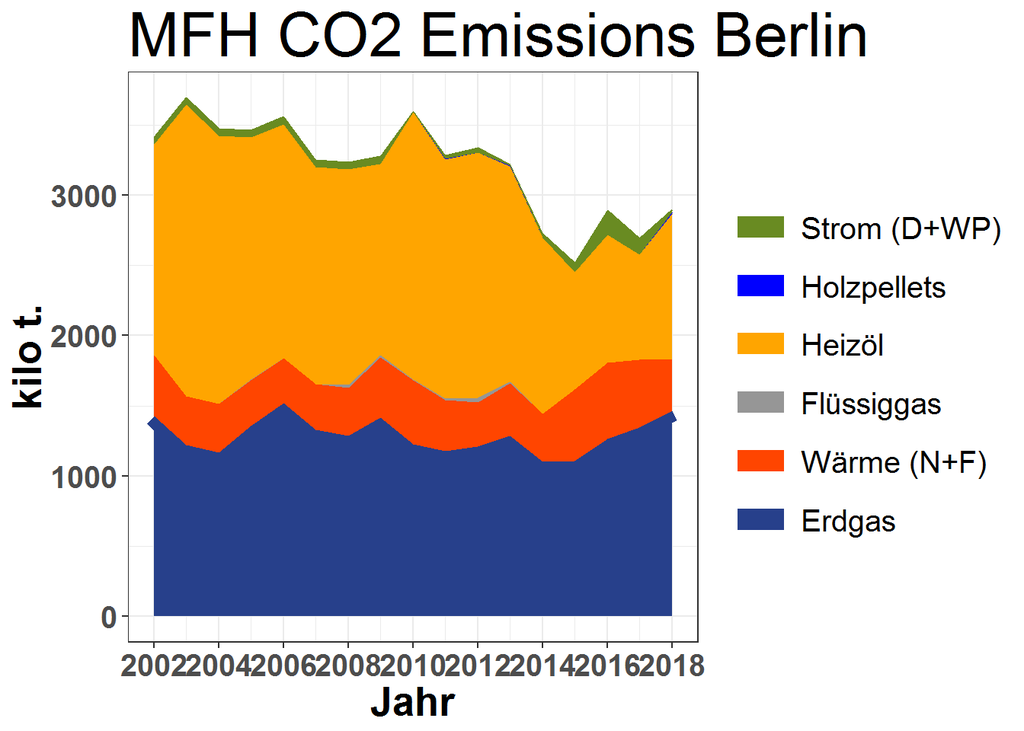

```r
plot_byET(co2_mfh_allebezirke_byET_cumsums , xlabel = "Jahr" , ylabel = "kilo t." , plottitle = "MFH CO2 Emissions Berlin")
```

```r
i_subsubsection <- i_subsubsection + 1
```

### 3.1.2. Stadtbezirke, Mehrfamiliengebäude, CO2-Emissionen aus der Beheizung von Wohnraum 2002 - 2018 summiert in 1.000 t

- Here CO2 emissions split by the bezirke

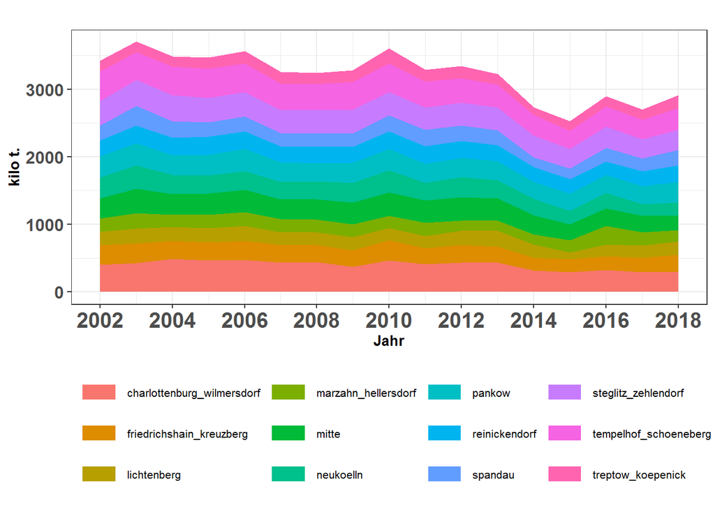

```r
berlin_co2_mfh_cumsums <- getCumSums(obj=berlin_co2_mfh , dropCols=c("abrechnungsjahr","total"))
plot_byBezirke(berlin_co2_mfh_cumsums , xlabel = "Jahr" , ylabel = "kilo t." , plottitle="")
```

```r
i_subsubsection <- i_subsubsection + 1
```

### 3.1.3. Stadtbezirke, Mehrfamiliengebäude, CO2-Emissionen aus der Beheizung von Wohnraum 2002 - 2018 in Prozent

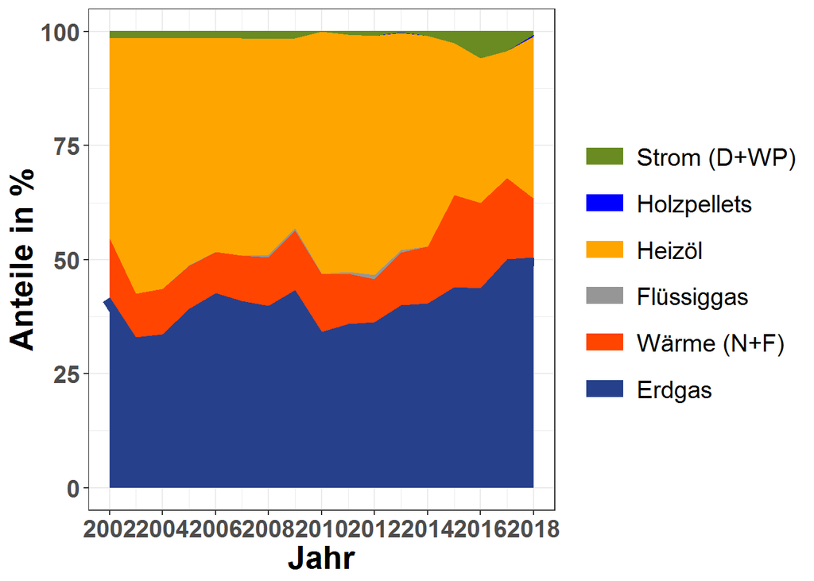

```r
co2_mfh_allebezirke_byET_prop <- find_proportions(co2_mfh_allebezirke_byET , drop_cols = c("abrechnungsjahr","total"))
co2_mfh_allebezirke_byET_prop_cumsums <- getCumSums(obj=co2_mfh_allebezirke_byET_prop , dropCols = "abrechnungsjahr")
plot_byET(co2_mfh_allebezirke_byET_prop_cumsums,xlabel = "Jahr" , ylabel = "Anteile in %" , plottitle = NULL)
```

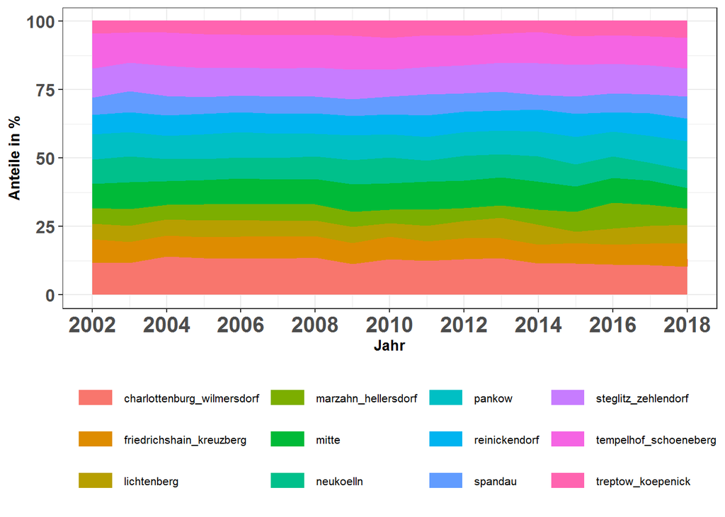

```r
berlin_co2_mfh_prop <- find_proportions(berlin_co2_mfh,drop_cols=c("abrechnungsjahr","total"))
berlin_co2_mfh_prop_cumsums <- getCumSums(berlin_co2_mfh_prop,dropCols="abrechnungsjahr")
plot_byBezirke(berlin_co2_mfh_prop_cumsums,xlabel = "Jahr" , ylabel = "Anteile in %" , plottitle = NULL)
```

```r
i_subsubsection <- i_subsubsection + 1
```

### 3.1.4. Stadtbezirke, Mehrfamiliengebäude, CO2-Emissionen aus der Beheizung von Wohnraum 2002 - 2018 in 1.000 t

- same as 3.1.2.

```r
i_subsubsection <- i_subsubsection + 1
```

### 3.1.5. Stadtbezirke, Mehrfamiliengebäude, CO2-Emissionen aus der Beheizung von Wohnraum 2002 – 2018, Veränderung in Prozent

- Pending

```r
i_subsubsection <- i_subsubsection + 1
```

### 3.1.6. Stadtbezirke, Mehrfamiliengebäude, Veränderung der CO2-Emission aus der Beheizung von Wohnraum 2002 - 2018 in Prozent

- Pending

```r
i_subsection <- i_subsection + 1
i_subsubsection <- 1
```